# Mathematics Anxiety Survey Report - For Reg Paper 01

Cheng Peng & Laura Pyatt

West Chester University

# 1 Introduction

The subject of mathematics causes fear and difficulty for a wide range of students. We often hear students claim, “I don’t like math”, “I’m just not good at math”, “I’m not a math person”, or “I wasn’t born with the math gene”, etc. Although these claims are not perfect indicators of math anxiety, students who have these fixed mindsets will be more likely to experience math anxiety.

While math anxiety can have a serious impact on academic performance, it does not mean a lack of mathematics ability. Prof. Laurent Schwartz experienced math anxiety in the 11th grade, but this did not prevent him from becoming a prominent mathematician. In fact, he won the Fields Model (the mathematician’s Nobel Prize) in 1950. Effectively managing math anxiety requires a deep understanding of math anxiety.

This project aims to identify factors that are strongly associated with math anxiety and use them to reduce math anxiety and, consequently, improve academic performance. Specifically:

1. The results of this project will contribute to the body of existing knowledge.
2. Identification of environmental factors aids the development of intervention tools for educators and support staff to help students reduce math anxiety and improve their academic performance.
3. The outcomes of this project can be used to implicitly improve retention.

# 2 Literature Review

Mathematics anxiety involves feelings of fear, tension, apprehension, and physiological reactivity interfering when individuals engage with number manipulation and mathematical problem-solving (see, for example, Pletzer et al. 2016). In the U.S., an estimated 25% of four-year college students and up to 80% of community college students suffer from a moderate to a high degree of mathematics anxiety (Chang & Beilock, 2016). The frequency of negative effects of math anxiety on college students is increasing.

The earliest research on math anxiety can be traced back to Gough (1954) who used the term mathemaphobia. The term math anxiety was first used by Dreger and Aiken (1957). The first definition of math anxiety is credited to Richardson and Suinn (1972), who described math anxiety as “feelings of tension and anxiety that interfere with the manipulation of numbers and solving of mathematical problems in a wide variety of ordinary life and academic situations”.

In the past 70 years, numerous authors conducted extensive research on math anxiety. Particularly, in the past 20 years, researchers from different disciplines including mathematics have investigated the association between math anxiety and math achievement, the causes of math anxiety, characteristics of students that increase susceptibility to math anxiety, and efforts that educators can take to remedy it.

Math anxiety is real. Its negative impact on students’ academic performance and their future professional life is profound. Extensive research publications since 2000 have shown that math anxiety relates inversely to positive attitudes toward mathematics and is bound directly to avoidance of the subject (see for example, Segool et al., 2013). It affects both math and overall academic performance since math anxiety leads to the drainage of cognitive resources, motivation reduction, and strategy impairment (Klee et al., 2022).

Math anxiety can also lead to poor academic performance and course withdrawal, putting students behind schedule and increasing the risk of drop out, which reduces student retention rates. Wilson (2013) studied math anxiety of mature-age pre-service teachers as a potential contributing factor that impacts student retention. Daker et al. (2021) recently studied the impact of math anxiety on first-year STEM students and concluded that math anxiety predicts STEM avoidance and underperformance throughout the university, independently of math ability.

A wealth of empirical studies on various aspects of math anxiety have been conducted since Dreger & Aiken’s (1957) seminal work. Due to the complex pathways toward the development of math anxiety and its links with achievements and confounders, the origins and outcomes of math anxiety are still not fully understood.

Recent and ongoing research focuses on the development and dynamic interplay between factors that cause math anxiety. Most of the research can be classified into three categories: situational, dispositional, and environmental (O’Leary et al., 2017). The current project will explore all three types of factors, but the primary focus is on the environmental factors such as prior perceptions, attitudes, and experiences that have affected the individual.

# 3 Research Objectives

Since lower mathematics achievement predicts higher subsequent math anxiety and higher math anxiety predicts lower future achievement, reducing math anxiety will help students develop a positive attitude to mathematics, build confidence, boost motivation, and consequently improve their achievements. This study aimed to identify the factors that can reduce math anxiety in college students. Specific objectives are

**Objective 1**: Adopting well-established psychometric survey instruments AMAS and self-efficacy instruments to collect math anxiety and self-efficacy data.

**Objective 2**: Include some demographic characteristics such as age and gender to compare the results with that of existing research and use them as a baseline.

**Objective 3**: Teaching strategies can reduce math anxiety and improve learning outcomes. We will investigate several different strategies in mathematics teaching such as conceptual, procedure, etc., to see if these strategies affect the level of math anxiety.

**Objective 4**: Effectively using the technologies can reduce math anxiety. The recently developed educational technologies during the pandemic have not been discussed in the literature on math anxiety. We will investigate how these new technologies affect math anxiety.

**Objective 5**: Learning modalities and styles are also associated with math anxiety. Most of the research in this direction is based on high school students. We will explore how these learning modalities and styles affect math anxiety among college students.

**Objective 6**: Creating and using campus learning resources can reduce math anxiety and improve their academic performance (Moliner & Alegre, 2020). We will explore whether and how learning resources on college campuses reduce anxiety.

# 4 Materials

## 4.1 Participants

The study population in this study is defined as WCU students aged 18 years or older who took their first MAT class at WCU. The results in this study can be generalized to similar regional universities and those recently reclassified R2 institutions.

## 4.2 Survey Instruments

# 5 Raw Data Processing

At the end of data collection, we received 895 responses. Of these, 199 participants did not complete the main survey subscales. The analysis is based on the remaining 696 responses for which the main subscales were completed, which contained only a few missing values. Several redundant variables were removed from the raw data. In addition, some original categorical variables were recategorized to avoid sparse groups and improve interpretability.

## 5.1 Missing Value Imputation

To main this sample size, we use random imputation approach to fill in the missing values. Since all multi-item sub-scales were measured using a Likert scale, the scores follows a multinomial distribution. The empirical distribution will be used in the random imputation to main the probability distribution of the observed data. The following code imputes the missing values in all multi-item subscales.

```r
Imputation = function(DataName){
  for (i in 1:(dim(DataName)[2])){
    vec = as.vector(DataName[, i])
    na.id = which(is.na(vec))
    n0 = length(na.id)
    prob0 = table(vec)/length(vec)
    imput.val = NULL
      for (j in 1:n0){
      imput.val[j] = sample(1:length(prob0), size = 1, prob = prob0)
    }
    DataName[na.id, i] = imput.val
  }
   DataName
}
```

## 5.2 Reverse Scoring

**Reverse scoring** is a crucial data preparation step for multi-item surveys where some items are worded in the opposite direction to prevent response bias. After item-wise review of all instruments along with statistical procedures of correlation and confirmatory factor analysis (CFA), item 2 in the *Self-efficacy Instrument* and **all questions** except items 5 and 7 in the *Technology Instrument* were negatively worded. The scores of these items were reversed.

In addition, all questions regarding engagement and resource use were reverse-worded, so their scores were reversed for the subsequent analysis.

## 5.3 Sparse Category Regrouping

Two variables need to be regrouped in the following: course level and ethnicity.

- **Math Course Level**
  - *Math.I*: MATQ30, MAT100 (Math for Teacher I), MAT101 (Math for Teacher I), MAT102 (Math for Teacher II),
  - *Math.II*: MAT103 (Intro Math), MAT104 (Intor Applied Math), MAT112 (Algebra and Functions with Support), MAT113 (Algebra and Functions), MAT115 (Algebra, Functions, and Trigonometry), MAT131 (Pre-calc)
  - *Math.III*: MAT143 (Brief Calc.), MAT145 (Calc. for Biology), MAT151 (Discrete Math), MAT161 (Calc. I)
  - *Math.IV*: MAT162-MAT480 (Math Course beyond Calc I)
  - *Stats*: MAT121 (stats I), MAT125 (Stats and Prob.), STA200 (Stats II)
  - *Other*: All courses not listed above
- **Ethnicity**
  - *White*
  - *Black*: Black and African American
  - *Asian*
  - *Other*: Native Hawaiian or Pacific Islander, Multiple Ethnicity or Other, Prefer Not To Answer
- **Learning Modalities**

```r
df_with_freq <- Comp.Modality %>%
  rowwise() %>%
  mutate(
    freq_A = sum(c_across(MS.1:MS.12) == "1"),
    freq_B = sum(c_across(MS.1:MS.12) == "2"),
    freq_C = sum(c_across(MS.1:MS.12) == "3")
  ) %>%
  ungroup()
###
df_with_freq$max_freq_col <- names(df_with_freq)[max.col(df_with_freq[, c("freq_A", "freq_B", "freq_C")]) + 1]
df_with_freq$max_freq_value <- apply(df_with_freq[, c("freq_A", "freq_B", "freq_C")], 1, max)
df_with_freq$modality <- ifelse(df_with_freq$max_freq_col=="MS.1", "Auditory",
                                ifelse(df_with_freq$max_freq_col=="MS.2", "Visual", "Kinesthetic"))
```

```r
Anxiety.mea <- Comp.Anxiety[, c("ID",  "AMAS.2", "AMAS.4", "AMAS.5",  "AMAS.8")]
Anxiety.mla <- Comp.Anxiety[, c("ID", "AMAS.1", "AMAS.3", "AMAS.6", "AMAS.7", "AMAS.9")]
```

## 5.4 Exploratory Factor Analysis (EFA) on Anxiety

The abbreviated mathematical anxiety (MA) instrument developed by Hopko et al. (2003) is characterized by a two-factor structure that divides into two subscales: mathematics evaluation anxiety (MEA) and mathematics learning anxiety (MLA). The subsequent exploratory factor analysis serves to validate this construct.

The following $\chi^2$ test and KMO index (Measure of Sampling Adequacy - MSA) are used to assessing adequacy of factor analysis. Kaiser (1975) suggested that KMO > .9 were marvelous, in the .80s, mertitourious, in the .70s, middling, in the .60s, medicore, in the 50s, miserable, and less than .5, unacceptable.

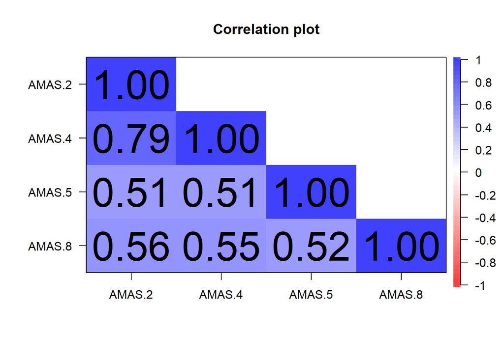

```r
# Check correlations (visually)
n = dim(Comp.Anxiety[,-1])[1]
cor_matrix <- cor(Anxiety.mea[,-1])
corPlot(cor_matrix, upper = FALSE)
```

```r
validity <- function(invar, varname){
  cor_matrix <- cor(invar[,-1])
  n = dim(invar)[1]
  # Bartlett's Test of Sphericity (we want a significant p-value, p < .05)
  bart <- cortest.bartlett(cor_matrix, n = n)
  # KMO Measure of Sampling Adequacy (MSA) (We want overall MSA > 0.6, ideally > 0.8)
  KMO <- KMO(cor_matrix)
  ###
  varname <- varname
  KMO.score <- KMO$MSA
  chisq <- bart$chisq
  pval <- bart$p.value
  df <- bart$df
  data.frame(var.name = varname, MSA = KMO.score, Bartlett = chisq, DF = df, p.value = pval)
}
```

```r
mea <- validity(invar=Anxiety.mea, varname="Anxiety.mea")
mla <- validity(invar=Anxiety.mla, varname="Anxiety.mla")
SelfEfficacy <- validity(invar=Comp.SelfEfficacy, varname="SelfEfficacy")
Cooporative <- validity(invar=Comp.Cooporative, varname="Cooporative")
LectureType <- validity(invar=Comp.LectureType, varname="LectureType")
Deductive<- validity(invar=Comp.Deductive, varname="Deductive")
Inductive <- validity(invar=Comp.Inductive, varname="Inductive")
Demonstration <- validity(invar=Comp.Demonstration, varname="Demonstration")
Repetitive <- validity(invar=Comp.Repetitive, varname="Repetitive")
Integrative <- validity(invar=Comp.Integrative, varname="Integrative")
Technology <- validity(invar=Comp.Technology, varname="Technology ")
Engage <- validity(invar=Comp.Engage, varname="Engage")
Resource <- validity(invar=Comp.Resource, varname="Resource")
#Modality <- validity(invar=Comp.Modality, varname="Modality")
cfa.validity <- rbind(mea, mla, SelfEfficacy, Technology, Cooporative, Deductive, Demonstration, Inductive, Integrative,  LectureType, Repetitive, Engage, Resource)
pander(cfa.validity)
```

| var.name | MSA | Bartlett | DF | p.value |
| --- | --- | --- | --- | --- |
| Anxiety.mea | 0.7653 | 1263 | 6 | 1.314e-269 |
| Anxiety.mla | 0.8305 | 993.5 | 10 | 4.774e-207 |
| SelfEfficacy | 0.5342 | 412.9 | 3 | 3.618e-89 |
| Technology | 0.9259 | 5134 | 45 | 0 |
| Cooporative | 0.872 | 2137 | 15 | 0 |
| Deductive | 0.8955 | 2160 | 21 | 0 |
| Demonstration | 0.8999 | 2186 | 21 | 0 |
| Inductive | 0.9115 | 2303 | 21 | 0 |
| Integrative | 0.8518 | 1565 | 21 | 3.413e-319 |
| LectureType | 0.916 | 2608 | 21 | 0 |
| Repetitive | 0.886 | 2480 | 21 | 0 |
| Engage | 0.7252 | 807.1 | 3 | 1.232e-174 |
| Resource | 0.6856 | 723.6 | 6 | 4.784e-153 |

```r
# Get eigenvalues
fa_result <- fa(Comp.Anxiety[,-1], nfactors = ncol(Comp.Anxiety[,-1]), rotate = "none")
eigenvalues <- fa_result$e.values

# Scree plot with horizontal line using shapes
scree_plot <- plot_ly(x = 1:length(eigenvalues), y = eigenvalues,
                      type = 'scatter', mode = 'lines+markers',
                      line = list(width = 3),
                      marker = list(size = 8)) %>%
  layout(
    title = "Scree Plot with Kaiser Criterion (Eigenvalue)",
    xaxis = list(title = "Factor Number"),
    yaxis = list(title = "Eigenvalue"),
    shapes = list(
      list(
        type = "line",
        x0 = 0,
        x1 = length(eigenvalues),
        y0 = 1,
        y1 = 1,
        line = list(color = "red", width = 2, dash = "dash")
      )
    ),
    annotations = list(
      list(
        x = length(eigenvalues) * 0.8,
        y = 1.1,
        text = "Kaiser Criterion (λ = 1)",
        showarrow = FALSE,
        font = list(color = "red")
      )
    ),
     margin = list(
                  t = 100,  # Adjust this value to increase or decrease the top margin
                  b = 50,
                  l = 50,
                  r = 50)
  )

scree_plot
```

[interactive chart not shown]

Next, we perform EFA to identify the items of MEA and MLA through factor loadings.

```r
## two-factor aEFA
efa_2factor <- fa(Comp.Anxiety[,-1], nfactors = 2, rotate = "oblimin",
                  fm = "pa", scores = "regression")
# Create a clean loadings table
loadings_table <- fa.sort(efa_2factor$loadings[])
pander(loadings_table, digits = 2, cutoff = 0.3)
```

|  | PA2 | PA1 |
| --- | --- | --- |
| **AMAS.2** | 0.82 | 0.063 |
| **AMAS.4** | 0.81 | 0.049 |
| **AMAS.8** | 0.78 | -0.13 |
| **AMAS.5** | 0.57 | 0.12 |
| **AMAS.3** | -0.015 | 0.73 |
| **AMAS.7** | -0.07 | 0.73 |
| **AMAS.6** | 0.051 | 0.69 |
| **AMAS.9** | 0.14 | 0.63 |
| **AMAS.1** | 0.016 | 0.5 |

As shown in the table above, items 2, 4, 5, and 8 load onto the evaluation anxiety factor, whereas the remaining items load onto the learning anxiety factor. Our data confirms the two distinct subscales in the instrument. We will use CFA to calculate the FA scores for each records later.

```r
Anxiety.mea <- Comp.Anxiety[, c("ID",  "AMAS.2", "AMAS.4", "AMAS.5",  "AMAS.8")]
Anxiety.mla <- Comp.Anxiety[, c("ID", "AMAS.1", "AMAS.3", "AMAS.6", "AMAS.7", "AMAS.9")]
```

# 6 Validation and Reliability

The major multi-item instruments used in this study are well-established and have been used in various published research. In practice, the validity and reliability of such established instruments must be confirmed before any statistical analysis. We next perform reliability and validity analyses to warrant the credibility of the overall survey design and the quality of the collected data.

## 6.1 Validity Analysis

**Validity** of a multi-item survey instrument answers the question: “Am I actually measuring what I intend to measure?” It’s about the soundness of the interpretation of the scores. In psychometrics, **validity** refers to the degree to which a scale measures what it claims to measure. For a single-factor instrument, this means all items are indicators of one underlying construct such as maths anxiety, self-efficacy, engagement, etc. in this comprehensive survey. The CFA has been used in survey research widely, see Watson, et al (1988) and Marsh (1996).

**Confirmatory Factor Analysis (CFA)** is a powerful statistical technique used to test a pre-specified theory about the structure of your instrument. We use CFA to confirm that your hypothesized single-factor model is consistent with the observed data. It provides rigorous evidence for construct validity in a list of conventional measures:

- **Factor Loadings** are the standardized weights from the Confirmatory Factor Analysis (CFA). The suggested guidelines are:
  - A loading **magnitude greater than 0.5** indicates that the item shares at least 25% of its variance with the latent factor. In the following table, we report the minimum loading for each instrument under the column `std.all.min`.
  - All loadings must be statistically significant (p < 0.05). We report the maximum p-value for each instrument under the column `pval.max`.
- **Standardized Root Mean Square Residual (SRMR)** measures the goodness-of-fit of the CFA model. It represents the average standardized residual between the observed and predicted correlation matrices. A lower value indicates a better fit, with a suggested cutoff of **less than 0.08**.
- **Comparative Fit Index (CFI)** is another goodness-of-fit measure for the CFA. It compares the specified model to a null (independence) model. A higher value indicates a better fit, with a suggested cutoff of **greater than 0.9**.
- **Tucker-Lewis Index (TLI)** also measures the goodness-of-fit of the CFA. Its interpretation and usage are similar to those of the CFI.

After some exploratory analysis, we dropped a few items from the Technology Instrument and defined two sucscales of the initial resource instruments: **use of resource** and **student engagement**.

The final results on the struct validity measures are summarized in the following table.

```r
cfa.analysis <- function(dataset){
  #dataset <- Comp.Anxiety
  predictors <- names(dataset[, -1])
  n0 <- length(predictors)
  cfa.model <-  paste("latent =~", paste(predictors, collapse = " + "))
  cfa.fit <- cfa(cfa.model, data = dataset[, -1], estimator = "MLM")
  results <- summary(cfa.fit, standardized = TRUE, fit.measures = TRUE, rsquare = TRUE)
  std.all.min <- min(results$pe$std.lv[1:n0])
  pval.max <- max(results$pe$pvalue[2:n0])
  srmr <- results$fit["srmr"]
  cfi <- results$fit["cfi"]
  tli <- results$fit["tli"]
  #rmsea <- results$fit["rmsea"]
  cbind(std.all.min = std.all.min, pval.max = pval.max, srmr = srmr, cfi = cfi,  tli = tli)
}
```

```r
anxiety.mea.vlid <-cfa.analysis(Anxiety.mea)
anxiety.mla.vlid <-cfa.analysis(Anxiety.mla)
#anxiety.vlid <-cfa.analysis(Comp.Anxiety)
efficacy.vlid <-cfa.analysis(Comp.SelfEfficacy)
tech.vlid <-cfa.analysis(Comp.Technology)
cooperative.vlid <-cfa.analysis(Comp.Cooporative)
deductive.vlid <-cfa.analysis(Comp.Deductive)
demo.vlid <-cfa.analysis(Comp.Demonstration)
inductive.vlid <-cfa.analysis(Comp.Inductive)
integrate.vlid <-cfa.analysis(Comp.Integrative)
lecture.vlid <-cfa.analysis(Comp.LectureType)
repetive.vlid <-cfa.analysis(Comp.Repetitive)
engage.vlid <-cfa.analysis(Comp.Engage)
resource.vlid <-cfa.analysis(Comp.Resource)
##
vlid.table <-rbind(anxiety.mea = anxiety.mea.vlid,
                   anxiety.mla = anxiety.mla.vlid,
                  self.efficacy = efficacy.vlid,
                  technology = tech.vlid, cooperative = cooperative.vlid,
                  deductive = deductive.vlid, demonstration = demo.vlid,
                  inductive = inductive.vlid, integrate = integrate.vlid,
                  lecture = lecture.vlid, repetitive = repetive.vlid,
                  engage = engage.vlid, resource = resource.vlid)
row.name <- c("anxiety.mea", "anxiety.mla", "self.efficacy",
              "technology", "cooperative",
              "deductive", "demonstration", "inductive", "integrate",
              "lecture", "repetitive", "engage", "resource")
col.name <- c("std.all.min", "pval.max", "srmr", "cfi",  "tli")
rownames(vlid.table) <- row.name
colnames(vlid.table) <- col.name
pander(vlid.table[, -c(1,2)])
```

|  | srmr | cfi | tli |
| --- | --- | --- | --- |
| **anxiety.mea** | 0.04188 | 0.9722 | 0.9166 |
| **anxiety.mla** | 0.02031 | 0.9907 | 0.9814 |
| **self.efficacy** | 1.052e-08 | 1 | 1 |
| **technology** | 0.08125 | 0.823 | 0.7724 |
| **cooperative** | 0.04457 | 0.932 | 0.8867 |
| **deductive** | 0.0469 | 0.9463 | 0.9194 |
| **demonstration** | 0.03764 | 0.956 | 0.934 |
| **inductive** | 0.02972 | 0.9719 | 0.9578 |
| **integrate** | 0.05439 | 0.9219 | 0.8828 |
| **lecture** | 0.02589 | 0.9779 | 0.9669 |
| **repetitive** | 0.05566 | 0.9095 | 0.8643 |
| **engage** | 2.466e-08 | 1 | 1 |
| **resource** | 0.07761 | 0.8662 | 0.5986 |

**Remarks**: (1). The above validity measures based on the items follow multi-variate normal distribution, This is a strong assumption. The items in each instrument are not continuous. This influences some of the validity measure. (2). In practice, we can use some descriptive approaches to visual check with assuming multi-variate normality.

## 6.2 Reliability Analysis

**Reliability** of a multi-item survey instrument answers the question: “If I measure the same thing multiple times, will I get a consistent result?” It measures how well the items that are supposed to measure the same construct hang together.

**Internal Consistency** is the most common assessment for a survey administered once. It measures the degree to which items in a scale are correlated with each other. Two well-known internal consistency measures are Cronbach’s Alpha (Cronabck, 1951) and McDonald’s Omega (1999). **McDonald’s Omega** is more robust than **Cronbach’s Alpha**.

**Cronbach’s Alpha** and **McDonald’s Omega** typically range from 0 to 1. The suggested cut-offs are given below.

- `> 0.9`: Excellent
- `0.8 - 0.9`: Good
- `0.7 - 0.8`: Acceptable
- `< 0.7`: Poor (may have items that don’t “belong”)

```r
anxiety.mea.rel <- Reliability.fun(Anxiety.mea)
anxiety.mla.rel <- Reliability.fun(Anxiety.mla)
#anxiety.rel <- Reliability.fun(Comp.Anxiety)
efficacy.rel <- Reliability.fun(Comp.SelfEfficacy)
tech.rel <- Reliability.fun(Comp.Technology)
cooperative.rel <- Reliability.fun(Comp.Cooporative)
deductive.rel <- Reliability.fun(Comp.Deductive)
demo.rel <- Reliability.fun(Comp.Demonstration)
inductive.rel <- Reliability.fun(Comp.Inductive)
integrate.rel <- Reliability.fun(Comp.Integrative)
lecture.rel <- Reliability.fun(Comp.LectureType)
repetive.rel <- Reliability.fun(Comp.Repetitive)
#after.rel <- Reliability.fun(Comp.AfterClass)
#in.class.rel <- Reliability.fun(Comp.InClass)
engage.rel <- Reliability.fun(Comp.Engage)
resource.rel <- Reliability.fun(Comp.Resource)
##
Rel.table <-rbind(anxiety.mea = anxiety.mea.rel, anxiety.mla = anxiety.mla.rel,
                  self.efficacy = efficacy.rel,
                  technology = tech.rel, cooperative = cooperative.rel,
                  deductive = deductive.rel, demonstration = demo.rel,
                  inductive = inductive.rel, integrate = integrate.rel,
                  lecture = lecture.rel, repetitive = repetive.rel,
                  engage = engage.rel, resource = resource.rel)
row.name <- c("anxiety.mea", "anxiety.mla",
              "self.efficacy", "technology", "cooperative",
              "deductive", "demonstration", "inductive", "integrate",
              "lecture", "repetitive", "engage", "resource")
col.name <- c("Cronbach", "Omega")
rownames(Rel.table) <- row.name
colnames(Rel.table) <- col.name
pander(Rel.table)
```

|  | Cronbach | Omega |
| --- | --- | --- |
| **anxiety.mea** | 0.8428 | 0.8476 |
| **anxiety.mla** | 0.8008 | 0.8039 |
| **self.efficacy** | 0.6631 | 0.7165 |
| **technology** | 0.926 | 0.9281 |
| **cooperative** | 0.888 | 0.8881 |
| **deductive** | 0.8776 | 0.8787 |
| **demonstration** | 0.8823 | 0.8828 |
| **inductive** | 0.8901 | 0.8904 |
| **integrate** | 0.8248 | 0.8289 |
| **lecture** | 0.8993 | 0.901 |
| **repetitive** | 0.8867 | 0.8882 |
| **engage** | 0.8349 | 0.835 |
| **resource** | 0.7477 | 0.7522 |

```r
pander(cbind(KMO=cfa.validity[, 2], vlid.table[, -c(1,2)], Rel.table))
```

|  | KMO | srmr | cfi | tli | Cronbach | Omega |
| --- | --- | --- | --- | --- | --- | --- |
| **anxiety.mea** | 0.7653 | 0.04188 | 0.9722 | 0.9166 | 0.8428 | 0.8476 |
| **anxiety.mla** | 0.8305 | 0.02031 | 0.9907 | 0.9814 | 0.8008 | 0.8039 |
| **self.efficacy** | 0.5342 | 1.052e-08 | 1 | 1 | 0.6631 | 0.7165 |
| **technology** | 0.9259 | 0.08125 | 0.823 | 0.7724 | 0.926 | 0.9281 |
| **cooperative** | 0.872 | 0.04457 | 0.932 | 0.8867 | 0.888 | 0.8881 |
| **deductive** | 0.8955 | 0.0469 | 0.9463 | 0.9194 | 0.8776 | 0.8787 |
| **demonstration** | 0.8999 | 0.03764 | 0.956 | 0.934 | 0.8823 | 0.8828 |
| **inductive** | 0.9115 | 0.02972 | 0.9719 | 0.9578 | 0.8901 | 0.8904 |
| **integrate** | 0.8518 | 0.05439 | 0.9219 | 0.8828 | 0.8248 | 0.8289 |
| **lecture** | 0.916 | 0.02589 | 0.9779 | 0.9669 | 0.8993 | 0.901 |
| **repetitive** | 0.886 | 0.05566 | 0.9095 | 0.8643 | 0.8867 | 0.8882 |
| **engage** | 0.7252 | 2.466e-08 | 1 | 1 | 0.8349 | 0.835 |
| **resource** | 0.6856 | 0.07761 | 0.8662 | 0.5986 | 0.7477 | 0.7522 |

# 7 Composite Scoring

The core purpose of constructing multi-item surveys is to measure complex concepts with greater accuracy, reliability, and depth than a single question ever could. All instruments used in this study are based on a single-factor construct using the Likert scales. The commonly used methods for defining single index to capture the information of the single-factor construct are classified in three categories

## 7.1 Summing the Raw Likert Scores

The simplest approach is to sum the raw Likert scores into a composite score that represents a single factor within the survey construct. This method is valid provided that all questionnaire items are equally important, as each captures a similar amount of information about the underlying factor.

However, this approach is violated in several critical scenarios, leading to a biased and unreliable composite score. For example, **Violation of Equal Importance**: The core assumption is that each item is a equally strong indicator of the construct. In reality, items often have different levels of importance. Summing items with high and low levels of importance equally gives undue weight to weaker indicators, effectively diluting the composite score with noise and reducing its validity. >**This method should never be used for rigorous analysis in psychometrics.**

## 7.2 FA Approach

Confirmatory Factor Analysis (CFA) is a very common and often practical approach to validating survey instruments and create (weighted) composite score. It is a distribution dependent statistical method. However, it comes with a set of distinct some disadvantages particularly the assumption of multi-variate normal distribution. Factor loadings in CFA are estimated based on the maximum likelihood which is defined based on multivariate normal distribution. We have used CFA to validate the instrument. Since all instruments in this study are single-factor constructs, we will calculate the single composite score for each instrument using CFA.

**Caution**: The direction of FA is arbitrary, to make FA score meaningful and consistent with average of score in Likert scale, we can determine the sign of FA in such a way that FA and average raw score are positively correlated.

## 7.3 Other Scoring Methods

Averaging and summing raw scores are frequently employed in descriptive analyses. Nevertheless, these methods are scientifically questionable and should be avoided when drawing statistical inferences.

Principal Component Analysis (PCA) scoring is less rigorous than Factor Analysis (FA) scoring but has some scientific merits comparing with the averaging and summing scoring methods. However, it should be used with caution:

- Retaining only the first principal component may entail considerable information loss in many applications.
- Although PCA scores often exhibit numerical distributions close to CFA scores, they do not carry the same rigorous psychometric interpretation.
- The arbitrary sign of PCA components also requires careful handling before use.

Accordingly, this report relies on well-established CFA scores for descriptive analysis, regression modeling, and visual analysis throughout.

```r
#####
 scores = function(df, dn){
  ###############
  # mean score
  ##############
  df.mean <- rowMeans(df[, -1])
  ###########################
  ## single factor score
  ##########################
  x.var <- names(df[, -1])
  n0 <- length(x.var)
  cfa.model <-  paste("latent =~", paste(x.var, collapse = " + "))
  cfa.fit <- cfa(cfa.model, data = df[, -1], estimator = "MLM")
  composite.cfa <- lavPredict(cfa.fit)
  ##########################
  # pca analysis
  ##########################
  pca.mdl <- prcomp(df[,-1], scale = TRUE)
  pca0 <- pca.mdl$x[, 1]
  r0 = cor(pca0, df.mean)
  if(r0 < 0) {
     pca.all <- -pca.mdl$x
  }else{
    pca.all <- pca.mdl$x
  }
  first.pca = pca.all[,1]
  ##########################
  # weighted pca score
  ##########################
  var.explained <-((pca.mdl$sdev)^2) / sum((pca.mdl$sdev)^2) #
  composite_weighted_pca <- as.matrix(pca.all) %*% (var.explained)

  outdata <- as.data.frame(cbind(avg = df.mean,
                           pca1 = first.pca,
                           wt.pca = as.vector(composite_weighted_pca),
                           cfa = as.vector(composite.cfa)))
  names(outdata) <- paste0(dn,".", names(outdata), sep = "")
  outdata
  }
###
Anxiety.mea.score = scores(Anxiety.mea, "Anxiety.mea")
Anxiety.mla.score = scores(Anxiety.mla, "Anxiety.mla")
#Anxiety.score = scores(Comp.Anxiety, "Anxiety")
SelfEfficacy.score = scores(Comp.SelfEfficacy0, "SelfEfficacy")
Technology.score = scores(Comp.Technology, "Technology")
Cooporative.score = scores(Comp.Cooporative, "Cooporative")
Deductive.score = scores(Comp.Deductive, "Deductive")
Demonstration.score = scores(Comp.Demonstration, "Demonstration")
Inductive.score = scores(Comp.Inductive, "Inductive")
Integrative.score = scores(Comp.Integrative, "Integrative")
LectureType.score = scores(Comp.LectureType, "LectureType")
Repetitive.score = scores(Comp.Repetitive, "Repetitive")
Engage.score = scores(Comp.Engage, "Engage")
Resource.score = scores(Comp.Resource, "Resource")
##
finalDat <- na.omit(cbind(demographics, Anxiety.mea.score,
                  Anxiety.mla.score, SelfEfficacy.score, Technology.score,
                  Cooporative.score, Deductive.score, Demonstration.score,Inductive.score,
                  Integrative.score, LectureType.score, Repetitive.score,
                  Engage.score, Resource.score))
```

Since the direction of FA and PCA is arbitrary, to make the FA score interpretable, we choose the direction of FA so that FA and average raw scores are positively correlated.

# 8 Some Graphical Exploration

We next explore the distributions of the created composite scores and perform some empirical comparisons. The primary goal of this survey study is to investigate factors that are associated with mathematics anxiety (MA) levels. To this end, we also look the distributions each individual items in the MA instrument.

## 8.1 Distribution of Demographics

The distribution of demographic factors are reported in the following figures.

```r
# Enhanced hover information
Demographic.bar <-function(in.cat, varname){
  freq.tbl <- table(in.cat)
  df <- data.frame(
      category <- names(freq.tbl),
      values <- as.vector(freq.tbl)
  )
  # High-contrast colors (manually defined)
  accessible_colors <- c(
  '#D55E00',  # Vermillion
  '#0072B2',  # Blue
  '#F0E442',  # Yellow
  '#009E73',  # Green
  '#56B4E9',  # Sky Blue
  '#E69F00',  # Orange
  '#CC79A7'   # Pink
  )
  fig <- plot_ly(df, x = ~category, y = ~values, type = 'bar',
                hoverinfo = 'text',
               text = ~paste('Category:', category, '<br>Value:', values, '<br>Percentage:', round(values/sum(values)*100, 1), '%'),
               #text = ~paste("Value:", values),
               textposition = 'auto',
               marker = list(
                 color = accessible_colors[1:nrow(df)],
                 line = list(color = 'black', width = 2)
               ),
               textfont = list(color = 'white', size = 12)) %>%
   layout(
   # title = list(text = varname,
                # font = list(size = 18, color = 'black')),
    xaxis = list(title = "Categories",
                 tickfont = list(color = 'black')),
    yaxis = list(title = "Values",
                 gridcolor = 'lightgray',
                 tickfont = list(color = 'black')),
    plot_bgcolor = 'white',
    paper_bgcolor = 'white',
    showlegend = FALSE,
    margin = list(
                  t = 100,  # Adjust this value to increase or decrease the top margin
                  b = 50,
                  l = 50,
                  r = 50)
  )
fig
}
```

```r
in.cat.sex <-  final.anxiety.dat$sex
in.cat.race <-  final.anxiety.dat$race
in.cat.class <-  final.anxiety.dat$class
in.cat.major <-  final.anxiety.dat$major
in.cat.math.level <-  final.anxiety.dat$math.level
in.cat.modality <-  final.anxiety.dat$modality
##
g.sex <- Demographic.bar(in.cat.sex, "Gender Distribution")
g.race <- Demographic.bar(in.cat.race, "Racial Distribution")
g.class <- Demographic.bar(in.cat.class, "Class Distribution")
g.major <- Demographic.bar(in.cat.major, "Major Distribution")
g.math.level <- Demographic.bar(in.cat.math.level, "Math Course Level")
g.modality <- Demographic.bar(in.cat.modality, "Learning Modality")
```

```r
# Assuming g.sex, g.race, g.class, g.major are plotly objects
plotly::subplot(g.sex, g.race, g.class, g.major, nrows = 2) %>%
  layout(
    annotations = list(
      list(x = 0.35, y = 0.99, text = "Gender",
           xref = "paper", yref = "paper", showarrow = FALSE, font = list(size = 14)),
      list(x = 0.75, y = 0.99, text = "Race",
           xref = "paper", yref = "paper", showarrow = FALSE, font = list(size = 14)),
      list(x = 0.35, y = 0.4, text = "Class Level",
           xref = "paper", yref = "paper", showarrow = FALSE, font = list(size = 14)),
      list(x = 0.75, y = 0.4, text = "Major",
           xref = "paper", yref = "paper", showarrow = FALSE, font = list(size = 14))
    ),
    showlegend = FALSE
  )
```

[interactive chart not shown]

```r
plotly::subplot(g.math.level, g.modality, nrows = 1) %>%
  layout(
    annotations = list(
      list(x = 0.35, y = 0.99, text = "Math Course Level",
           xref = "paper", yref = "paper", showarrow = FALSE,
           font = list(size = 14)),
      list(x = 0.75, y = 0.99, text = "Learning Modality",
           xref = "paper", yref = "paper", showarrow = FALSE,
           font = list(size = 14))
    ),
    showlegend = FALSE
    # Optional: add overall margins if needed
    # margin = list(t = 50, b = 50, l = 50, r = 50)
  )
```

[interactive chart not shown]

Only one category in variable **class** is less than 3% with 21 observations. Other variables don’t have issues on sparse categories.

## 8.2 Relationship Between Math Anxiety and Demographic Factors

A student’s demographic profile doesn’t determine their math anxiety, but it significantly influences which type of anxiety they are most vulnerable to and why. The next subsections present visual explorations of the relationship between demographic factors and the two dimensions of mathematical anxiety.

### 8.2.1 Mathematical Evaluation Anxiety

This is the anxiety a student feels when their mathematical ability is being formally or informally assessed. The primary fear is not of the math itself, but of the negative consequences of performing poorly. It’s performance-oriented. The stress comes from the situation of being evaluated, not necessarily from the content.

```r
## plotly for anxiety vs gender and other categorical demographic factor
gender.plotly <- function(in.var1, in.var2){
      gender.anxiety <- plot_ly(final.anxiety.dat,
                              x = ~sex,
                              y = ~Anxiety.mea.cfa,
                              color = as.formula(paste0("~",in.var1)),
                              type = "box",
                              boxpoints = "no",
                              jitter = 0.3,
                              pointpos = 0,
                              hoverinfo = "y + x + name",
                              hovertext = ~paste("Group:", in.var1,
                                                "<br>Factor:", sex,
                                                "<br>Score:", round(Anxiety.mea.cfa, 2)),
                              marker = list(size = 5, opacity = 0.7)) %>%
    layout(title = paste("Math Evaluation Anxiety (CFA): Gender vs ", in.var2,""),
         xaxis = list(title = ""),
         yaxis = list(title = "Evaluation Anxiety Score"),
         boxmode = "group",
         hoverlabel = list(bgcolor = "white", font = list(size = 12)),
         margin = list(
                  t = 100,  # Adjust this value to increase or decrease the top margin
                  b = 50,
                  l = 50,
                  r = 50)
         )

 gender.anxiety
}
```

```r
gender.math.level = gender.plotly("math.level", "Math Course Level")
gender.math.level
```

[interactive chart not shown]

```r
gender.race = gender.plotly("race", "Race")
gender.race
```

[interactive chart not shown]

```r
gender.class = gender.plotly("class", "Class")
gender.class
```

[interactive chart not shown]

```r
gender.major = gender.plotly("major", "Major")
gender.major
```

[interactive chart not shown]

```r
gender.modality = gender.plotly("modality", "Modality")
gender.modality
```

[interactive chart not shown]

Some of the patterns observed in this study are consistent with the existing literature.

- Female students have relatively higher evaluation anxiety level than male students.
- The discrepancy of evaluation anxiety level across ethnic groups also consistent with what reported in the existing literature.

### 8.2.2 Mathematical Learning Anxiety

Mathematical learning anxiety stems directly from the subject matter, where the primary source of distress is the act of engaging with mathematical concepts. This engagement triggers an internal state of confusion, frustration, and cognitive overload.

The next few figures examine the relationship between mathematical learning anxiety and demographic factors, using the same visual approach as we did for mathematical evaluation anxiety.

```r
## plotly for anxiety vs gender and other categorical demographic factor
gender.plotly <- function(in.var1, in.var2){
      gender.anxiety <- plot_ly(final.anxiety.dat,
                              x = ~sex,
                              y = ~Anxiety.mla.cfa,
                              color = as.formula(paste0("~",in.var1)),
                              type = "box",
                              boxpoints = "no",
                              jitter = 0.3,
                              pointpos = 0,
                              hoverinfo = "y + x + name",
                              hovertext = ~paste("Group:", in.var1,
                                                "<br>Factor:", sex,
                                                "<br>Score:", round(Anxiety.mla.cfa, 2)),
                              marker = list(size = 5, opacity = 0.7)) %>%
    layout(title = paste("Math Learning Anxiety (CFA): Gender vs ", in.var2,""),
         xaxis = list(title = ""),
         yaxis = list(title = "Learning Anxiety Score"),
         boxmode = "group",
         hoverlabel = list(bgcolor = "white", font = list(size = 12)),
         margin = list(
                  t = 100,  # Adjust this value to increase or decrease the top margin
                  b = 50,
                  l = 50,
                  r = 50)
         )

 gender.anxiety
}
```

```r
gender.math.level.mla = gender.plotly("math.level", "Math Course Level")
gender.math.level.mla
```

[interactive chart not shown]

```r
gender.class.mla = gender.plotly("class", "Class")
gender.class.mla
```

[interactive chart not shown]

```r
gender.race.mla = gender.plotly("race", "Race")
gender.race.mla
```

[interactive chart not shown]

```r
gender.major.mla = gender.plotly("major", "Major")
gender.major.mla
```

[interactive chart not shown]

```r
gender.modality.mla = gender.plotly("modality", "Modality")
gender.modality.mla
```

[interactive chart not shown]

## 8.3 The Gender Gap in Evaluation and Learning Anxiety

It turns out that, comparing to math learning anxiety, evaluation anxiety manifests the gender gap. This observation is supported by academic research. The key insight is that the gender gap in math performance is more strongly linked to the anxiety generated by the testing situation than by anxiety toward the subject matter itself (leading potential learning anxiety).

A robust body of evidence, from foundational meta-analyses (Hembree, 1990) to contemporary studies (Devine et al., 2012; Goetz et al., 2013), establishes that female students experience disproportionately high levels of math test anxiety—a factor more predictive of academic outcomes than learning anxiety. This finding illuminates the work of Else-Quest et al. (2010), demonstrating that the gender gap in math performance is profoundly shaped by anxiety in evaluative environments. Therefore, addressing the specific pressures of testing situations is essential for closing this gap.

The following figure illustrates the relationship between gender and the two types of math anxiety: learning anxiety and evaluation anxiety.

```r
mea0 <- final.anxiety.dat[, c("sex", "Anxiety.mea.cfa")]
mla0 <- final.anxiety.dat[, c("sex", "Anxiety.mla.cfa")]
names(mea0) = c("sex", "anxiety.score")
names(mla0) = c("sex", "anxiety.score")
mea.mla <- rbind(mea0, mla0)

anxiety.type <- c(rep("mea", dim(mea0)[1]), rep("mla", dim(mea0)[1]))
mea.mla$anxiety.type <- anxiety.type
####
df = na.omit(mea.mla)
# Create more complex grouped boxplot with statistical annotations
# Custom hover information
fig <- plot_ly(df,
               x = ~anxiety.type,
               y = ~anxiety.score,
               color = ~sex,
               type = "box",
               hoverinfo = "y+x+name",
               hovertemplate = paste(
                 "Gender: %{x}<br>",
                 "Anxiety Type: %{fullData.name}<br>",
                 "Anxiety Score: %{y:.2f}<br>",
                 "<extra></extra>"
               )) %>%
  layout(
    title = "Gender Disparities in Math Evaluation and Learning Anxiety",
    xaxis = list(title = ""),
    yaxis = list(title = "Anxiety Score"),
    boxmode = "group",
    hoverlabel = list(bgcolor = "white", font = list(size = 12)),
    margin = list( t = 100,  # Adjust this value to increase or decrease the top margin
                  b = 50,
                  l = 50,
                  r = 50)
  )

fig
```

[interactive chart not shown]

Our results are also consistent with existing results in literature.

# 9 Student Perceived Teaching Strategies, Math Anxiety, and Self-efficicay

The following heatmap illustrates the pairwise correlations between anxiety levels, student-perceived teaching strategies, and other associated cognitive factors. A negative correlation between anxiety and another composite score (shown in blue) indicates that anxiety decreases as that composite score increases.

```r
var.name <-c( "Anxiety.mea.cfa", "Anxiety.mla.cfa", "SelfEfficacy.cfa", "Technology.cfa",
              "Cooporative.cfa", "Deductive.cfa", "Demonstration.cfa",
              "Inductive.cfa", "Integrative.cfa", "LectureType.cfa",
              "Repetitive.cfa", "Engage.cfa", "Resource.cfa")
all.composite.scores <- final.anxiety.dat[, var.name]
names(all.composite.scores) <- c( "Anxiety.mea", "Anxiety.mla", "SelfEfficacy", "Technology",
              "Cooporative", "Deductive.", "Demonstration",
              "Inductive", "Integrative", "LectureType",
              "Repetitive", "Engage", "Resource.")

# Calculate correlation matrix
cor_matrix <- cor(all.composite.scores, use = "complete.obs")

# Convert to long format using melt
cor_long <- melt(cor_matrix)
names(cor_long) <- c("x", "y", "r")

# Remove self-correlations and upper triangle if desired
cor_long <- cor_long[cor_long$x != cor_long$y, ]

# Create interactive heatmap
plot_ly(cor_long, x = ~x, y = ~y, z = ~r, type = "heatmap",
        colorscale = "RdBu", zmin = -1, zmax = 1,
        hoverinfo = "text",
        text = ~paste("X:", x, "<br>Y:", y, "<br>r =", round(r, 3))) %>%
  layout(title = "Correlation Matrix",
         xaxis = list(title = ""),
         yaxis = list(title = ""),
         margin = list(l = 100, r = 50, b = 100, t = 50))
```

[interactive chart not shown]

The figure above shows that all perceived teaching strategies are negatively correlated with both types of anxiety. In addition, students with high levels of self-efficacy tend to have low levels of math anxiety. Furthermore, the composite score for technology use is negatively correlated with both learning and evaluation anxiety, implying that technology can help reduce math anxiety. Conversely, we also see that students who use more learning resources tend to have higher learning anxiety.

In the next few subsections, we analyze relationships between the scales in this survey and compare our results with those in the existing literature.

## 9.1 Interrelationship Between Evaluation and Learning Anxieties

A positive correlation was found between mathematics evaluation anxiety and mathematics learning anxiety, which is consistent with previous research.

Mathematics learning anxiety is often the broader, foundational issue, stemming from negative experiences and beliefs about one’s own mathematical ability. Mathematics test anxiety is a more specific, situational manifestation of this broader anxiety, triggered by the evaluative pressure of exams.

The primary relationship is cyclical: learning anxiety fosters test anxiety, and a negative test experience reinforces learning anxiety. Gierl and Bisanz (1995) highlighted this cyclical nature. They suggested that early negative experiences with math (leading to learning anxiety) set the stage for later test anxiety. Conversely, a single traumatic test experience (e.g., a disastrous final exam) can generalize to a long-lasting, pervasive anxiety toward all math-related activities, solidifying learning anxiety. Zakaria et al. (2012) found a significant positive correlation between general mathematics anxiety and test anxiety. Students who are already anxious in daily math classes are primed for heightened anxiety when the stakes are raised in a test.

Both anxieties often stem from common roots, which explains their high positive inter-relationship.

- **Negative Past Experiences**: Repeated failure or humiliation in math classes during K-12 education is a powerful predictor for both types of anxiety in college (Maloney & Beilock, 2012).
- **Societal and Environmental Factors**: Cultural stereotypes (e.g., “math is for boys,” “some people just aren’t math people”) and teacher anxiety can be transmitted to students, fostering a general sense of apprehension toward the subject.
- **Fixed Mindset**: The work of Carol Dweck (2006) on mindset is highly relevant. Students with a “fixed mindset” (the belief that math ability is an innate, unchangeable trait) are more vulnerable to both learning and test anxiety. Any struggle is seen as evidence of a lack of ability, causing them to avoid challenging learning and to crumble under the evaluative pressure of tests.

## 9.2 Student Perceived Teaching Strategies

We can see from the above correlation matrix (heatmap) that the seven dimesions of student perceived teaching strategies are highly positively correlated. This positive correlation among diverse teaching strategies like cooperative, deductive, and lecture-type methods suggests that students do not necessarily view these approaches as mutually exclusive. Instead, they may perceive them as complementary tools within an effective instructor’s repertoire. The reasons for this observed intercorrelation can be attributed to several factors.

- **Instructor Versatility and Strategic Blending**: A single lesson might begin with a brief lecture to introduce a concept, use a demonstrative example, and then engage students in a cooperative problem-solving activity to apply the concept inductively. Students perceive this blending, leading to positive correlations among the strategies they observe.
- **Student Recognition of a Coherent Learning Cycle**: Students may perceive that different strategies serve different, but interconnected, purposes in their learning journey. For instance, a repetitive practice session might logically follow a deductive explanation of a formula to build fluency, and an integrative project might cap a unit to show real-world application. When these strategies are sequenced effectively, students see them as parts of a whole, coherent experience, leading to positive ratings across the board (Boaler, 2016).
- **The Halo Effect of Pedagogical Richness**: A classroom environment rich with varied pedagogical approaches is often more engaging. The positive affect generated by one engaging strategy (e.g., a fun cooperative activity) can create a “halo effect,” leading students to rate all the strategies used in that positive context more highly, even the more traditional ones like lecture-type instruction (Hattie, 2012).

However, these correlations can also be inflated by generalized student attitudes rather than precise reflections of discrete teaching acts. For example, the correlations might not reflect the actual frequency of use but a generalized student perception of their instructor. A student who holds a positive overall view of the teacher might rate all teaching strategies highly, regardless of how effectively each was individually deployed. This is a common form of response bias in student evaluations (Spooren et al., 2013).

The correlation might also be confounded due to lack of discriminant validity in perception. For ewxample, students, especially those without pedagogical training, may not finely discriminate between the nuanced definitions of each strategy. They might broadly perceive “the teacher explains things clearly,” which could lead them to rate deductive, demonstrative, and integrative strategies similarly because they all contribute to that overarching feeling of clarity.

## 9.3 The Triad of Anxiety, Self-Efficacy, and Teaching Strategies

Math self-efficacy, a concept derived from Albert Bandura’s social cognitive theory, refers to an individual’s conviction in their ability to successfully perform specific mathematical tasks. It is not a general feeling of confidence but a situation-specific belief and a robust predictor of perseverance, engagement, and academic success in mathematics (Bandura, 1997).

Conversely, math anxiety is a state of tension, apprehension, or fear that interferes with math performance. It is more than a simple dislike; it is a debilitating emotional reaction that can create a vicious cycle: anxiety leads to avoidance, which leads to poorer skills, which in turn heightens anxiety (Ashcraft, 2002).

These two constructs are typically strongly and inversely correlated. A student with high self-efficacy is less likely to experience anxiety when faced with a math problem, while a student with high anxiety will likely have their sense of efficacy eroded.

Critically, teaching strategies are not merely methods of content delivery; they are powerful environmental forces that directly shape students’ emotional and self-evaluative landscapes. Together, the triad of Perceived Teaching Strategies, Math Anxiety, and Math Self-Efficacy forms a dynamic, interconnected system that significantly influences a student’s math achievement and overall relationship with the subject.

The relationships within this triad are reciprocal. A student with high math self-efficacy may thrive in a fast-paced lecture, viewing it as an efficient way to acquire information. An anxious student in the same environment, however, may become overwhelmed and disengaged. Furthermore, students with high anxiety may actively avoid participating in cooperative groups for fear of being judged, thereby missing out on the very experiences that could build their confidence. In this way, a student’s pre-existing anxiety and self-efficacy directly shape their perception of and response to the learning environment itself.

```r
include_graphics("TechingStrategies-Anxiety-Self-efficacy.png")
```

[output not shown]

## 9.4 Lowess Regression Between Anxiety and Teaching Strategies

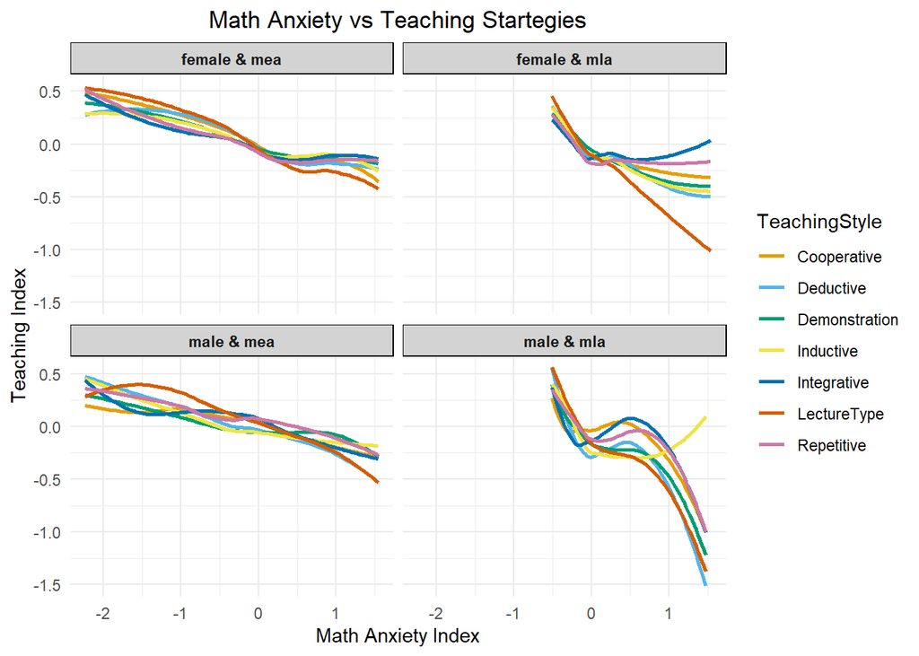

```r
# define a long table for group plots
## Test Anxiety
mea.tech.by.gender <- data.frame(
  anxety.index = rep(all.composite.scores$Anxiety.mea, 7),  # These are CFA scores!!!
  gender.anx.type = paste0(rep(final.anxiety.dat$sex, 7), " & mea"),
  teach.index = c(all.composite.scores$Cooporative, all.composite.scores$Deductive.,
                  all.composite.scores$Demonstration, all.composite.scores$Inductive,
                  all.composite.scores$Integrative, all.composite.scores$LectureType,
                  all.composite.scores$Repetitive),
  TeachingStyle = rep(c("Cooperative", "Deductive", "Demonstration", "Inductive",
                        "Integrative", "LectureType",  "Repetitive"), each = 693)

)
names(mea.tech.by.gender) <- c("anxety.index", "gender.anx.type", "teach.index", "TeachingStyle")
mea.tech.by.gender <- na.omit(mea.tech.by.gender)

## Learning Anxiety   4019
mla.tech.by.gender <- data.frame(
  anxety.index = rep(all.composite.scores$Anxiety.mla, 7),
  gender.anx.type = paste0(rep(final.anxiety.dat$sex, 7), " & mla"),
  teach.index = c(all.composite.scores$Cooporative, all.composite.scores$Deductive.,
                  all.composite.scores$Demonstration, all.composite.scores$Inductive,
                  all.composite.scores$Integrative, all.composite.scores$LectureType,
                  all.composite.scores$Repetitive),
  TeachingStyle = rep(c("Cooperative", "Deductive", "Demonstration", "Inductive",
                        "Integrative", "LectureType",  "Repetitive"), each = 693)

)
names(mla.tech.by.gender) <- c("anxety.index", "gender.anx.type", "teach.index", "TeachingStyle")
mla.tech.by.gender <- na.omit(mla.tech.by.gender)

colors_7 <-  c("#E69F00", "#56B4E9", "#009E73", "#F0E442",
                      "#0072B2", "#D55E00", "#CC79A7")
distinct_linetypes <- c("solid", "dashed", "dotted", "dotdash",
                        "longdash", "twodash", "22")
## Stacking
anxiety.sex.teach <- na.omit(rbind(mla.tech.by.gender, mea.tech.by.gender))


# Create ggplot with facets
gg <- ggplot(anxiety.sex.teach, aes(x = anxety.index, y = teach.index, color = TeachingStyle, group = TeachingStyle)) +
  #geom_point(alpha = 0.5, size = 1.5) +
  geom_smooth(method = "loess", span = 0.75, se = FALSE, size = 1) +
  facet_wrap(~ gender.anx.type, ncol = 2, nrow = 2) +
  scale_color_manual(values = colors_7) +
  scale_linetype_manual(values = distinct_linetypes) +
  #scale_color_viridis_d(option = "plasma") +
  labs(title = "Math Anxiety vs Teaching Startegies",
       x = "Math Anxiety Index",
       y = "Teaching Index") +
  theme_minimal() +
  theme(
    strip.background = element_rect(fill = "lightgray"),
    strip.text = element_text(face = "bold"),
    plot.title = element_text(hjust = 0.5)
  )

gg
```

## 9.5 Self-efficacy vs Teaching Strategies

```r
# define a long table for group plots
efficay.teach <- data.frame(
  efficacy.index <- rep(all.composite.scores$SelfEfficacy, 7),
  gender <- rep(final.anxiety.dat$sex,7),
  teach.index <-c(all.composite.scores$Cooporative, all.composite.scores$Deductive.,
                  all.composite.scores$Demonstration, all.composite.scores$Inductive,
                  all.composite.scores$Integrative, all.composite.scores$LectureType,
                  all.composite.scores$Repetitive),
  TeachingStyle = rep(c(" Cooperative", "Deductive", "Demonstration", "Inductive",
                        "Integrative", "LectureType",  "Repetitive"), each = 693)
)
names(efficay.teach) <- c("efficacy.index", "gender", "teach.index", "TeachingStyle")

# Create plot with smoothed lines
# Create ggplot with facets
gg <- ggplot(efficay.teach, aes(x = efficacy.index, y = teach.index, color = TeachingStyle, group = TeachingStyle)) +
  #geom_point(alpha = 0.5, size = 1.5) +
  geom_smooth(method = "loess", span = 0.75, se = FALSE, size = 1) +
  facet_wrap(~  gender, ncol = 2, nrow = 2) +
  scale_color_viridis_d(option = "plasma") +
  labs(title = "Multi-Panel Loess Plots:",
       x = "Math Self-efficacy",
       y = "Teaching Index") +
  theme_minimal() +
  theme(
    strip.background = element_rect(fill = "lightgray"),
    strip.text = element_text(face = "bold"),
    plot.title = element_text(hjust = 0.5)
  )

# Convert to interactive plotly
#ggplotly(gg) %>%
#  layout(
#    hovermode = "x unified",
#    legend = list(
#      orientation = "h",
#      x = 0.5,
#      xanchor = "center",
#      y = -0.1
#    )
#  )
```

## 9.6 Anxiety vs Other Factors

```r
# define a long table for group plots
mea.other <- data.frame(
  anxiety.index <- rep(all.composite.scores$Anxiety.mea, 4),
  gender <- paste0(rep(final.anxiety.dat$sex,4), " & mea"),
  factor.index <-c(all.composite.scores$SelfEfficacy, all.composite.scores$Technology,
                  all.composite.scores$Engage, all.composite.scores$Resource.),
  RelatedFactors = rep(c("SelfEfficacy", "Technology", "Engagement", "UseResource"), each = 693)
)
names(mea.other) = c("anxiety.index", "gender", "factor.index", "RelatedFactors")

# mla
mla.other <- data.frame(
  anxiety.index <- rep(all.composite.scores$Anxiety.mla, 4),
  gender <- paste0(rep(final.anxiety.dat$sex,4), " & mla"),
  factor.index <-c(all.composite.scores$SelfEfficacy, all.composite.scores$Technology,
                  all.composite.scores$Engage, all.composite.scores$Resource.),
  RelatedFactors = rep(c("SelfEfficacy", "Technology", "Engagement", "UseResource"), each = 693)
)
names(mla.other) = c("anxiety.index", "gender", "factor.index", "RelatedFactors")

anxitey.other <- rbind(mea.other, mla.other)

## plot panels
# Create ggplot with facets
gg <- ggplot(anxitey.other, aes(x = anxiety.index, y = factor.index, color = RelatedFactors, group = RelatedFactors)) +
  #geom_point(alpha = 0.5, size = 1.5) +
  geom_smooth(method = "loess", span = 0.75, se = FALSE, size = 1) +
  facet_wrap(~ gender, ncol = 2, nrow = 2) +
  scale_color_viridis_d(option = "plasma") +
  labs(title = "Multi-Panel Loess Plots:",
       x = "Math Learning Anxiety",
       y = "Other Factors") +
  theme_minimal() +
  theme(
    strip.background = element_rect(fill = "lightgray"),
    strip.text = element_text(face = "bold"),
    plot.title = element_text(hjust = 0.5)
  )

# Convert to interactive plotly
ggplotly(gg) %>%
  layout(
    hovermode = "x unified",
    legend = list(
      orientation = "h",
      x = 0.5,
      xanchor = "center",
      y = -0.1
    )
  )
```

[output not shown]

## 9.7 Closer Lowess Views: Anxiety vs Stratgeis by Learning Styles

```r
anxiety.anova <-final.anxiety.dat[, c("race","sex", "class", "major", "math.level","modality", "Anxiety.mea.cfa", "Anxiety.mla.cfa")]
names(anxiety.anova) <-c("race","sex", "class", "major", "math.level","modality", "Anxiety.mea", "Anxiety.mla")
final.anxiety.anova <- cbind(anxiety.anova ,all.composite.scores)

#final.anxiety.anova <- final.anxiety.anova[, c(-7,-8)]

##
modality.data <- data.frame(
  mla.index <- rep(final.anxiety.anova$Anxiety.mla, 7),
  gender <- rep(final.anxiety.dat$sex,7),
  factor.index <-c(final.anxiety.anova$Cooporative, final.anxiety.anova$Deductive.,
                   final.anxiety.anova$Demonstration, final.anxiety.anova$Inductive,
                   final.anxiety.anova$Integrative, final.anxiety.anova$LectureType,
                   final.anxiety.anova$Repetitive),
  RelatedFactors <- rep(c(" Cooperative", "Deductive", "Demonstration", "Inductive",
                        "Integrative", "LectureType",  "Repetitive"), each = 693),
  modalities <- rep(final.anxiety.anova$modality,7)
)
names(modality.data) <- c("mla.index", "gender", "factor.index", "RelatedFactors", "modalities")
```

```r
aud.ID <- which(modality.data$modalities==  "Auditory" )
auditory <- modality.data[aud.ID, ]
## ggplotly
# Create ggplot with facets
gg <- ggplot(auditory, aes(x = mla.index, y = factor.index, color = RelatedFactors, group = RelatedFactors)) +
  #geom_point(alpha = 0.5, size = 1.5) +
  geom_smooth(method = "loess", span = 0.75, se = FALSE, size = 1) +
  facet_wrap(~ gender, ncol = 2, nrow = 2) +
  scale_color_viridis_d(option = "plasma") +
  labs(title = "Loess Plots: Auditory Learner",
       x = "Math Learning Anxiety",
       y = "Teaching Strategy Index") +
  theme_minimal() +
  theme(
    strip.background = element_rect(fill = "lightgray"),
    strip.text = element_text(face = "bold"),
    plot.title = element_text(hjust = 0.5)
  )

# Convert to interactive plotly
#ggplotly(gg) %>%
#  layout(
#    hovermode = "x unified",
#    legend = list(
#      orientation = "h",
#      x = 0.5,
#      xanchor = "center",
#      y = -0.1
#    )
#  )
```

```r
viz.ID <- which(modality.data$modalities==  "Visual")
visual <-modality.data[viz.ID, ]


## ggplotly
# Create ggplot with facets
gg <- ggplot(visual, aes(x = mla.index, y = factor.index, color = RelatedFactors, group = RelatedFactors)) +
  #geom_point(alpha = 0.5, size = 1.5) +
  geom_smooth(method = "loess", span = 0.75, se = FALSE, size = 1) +
  facet_wrap(~  gender, ncol = 2, nrow = 2) +
  scale_color_viridis_d(option = "plasma") +
  labs(title = "Loess Plots: Visual Learner",
       x = "Math Learning Anxiety",
       y = "Teaching Strategy Index") +
  theme_minimal() +
  theme(
    strip.background = element_rect(fill = "lightgray"),
    strip.text = element_text(face = "bold"),
    plot.title = element_text(hjust = 0.5)
  )

# Convert to interactive plotly
#ggplotly(gg) %>%
#  layout(
#    hovermode = "x unified",
#    legend = list(
#      orientation = "h",
#      x = 0.5,
#      xanchor = "center",
#      y = -0.1
#    )
#  )
```

```r
kine.ID <- which(modality.data$modalities==  "Kinesthetic")
Kinesthetic <-modality.data[kine.ID, ]


## ggplotly
# Create ggplot with facets
gg <- ggplot(Kinesthetic, aes(x = mla.index, y = factor.index, color = RelatedFactors, group = RelatedFactors)) +
  #geom_point(alpha = 0.5, size = 1.5) +
  geom_smooth(method = "loess", span = 0.75, se = FALSE, size = 1) +
  facet_wrap(~  gender, ncol = 2, nrow = 2) +
  scale_color_viridis_d(option = "plasma") +
  labs(title = "Loess Plots: Kinesthetic Learner",
       x = "Math Learning Anxiety",
       y = "Teaching Strategy Index") +
  theme_minimal() +
  theme(
    strip.background = element_rect(fill = "lightgray"),
    strip.text = element_text(face = "bold"),
    plot.title = element_text(hjust = 0.5)
  )

# Convert to interactive plotly
#ggplotly(gg) %>%
#  layout(
#    hovermode = "x unified",
#    legend = list(
#      orientation = "h",
#      x = 0.5,
#      xanchor = "center",
#      y = -0.1
#    )
#  )
```

- **Less Anxious Students**:
  - More accurate perception of teaching styles
  - Better at distinguishing between different instructional approaches
  - More likely to notice subtle teaching nuances
- **More Anxious Students**:
  - Heightened sensitivity to perceived negative cues
  - More likely to interpret ambiguous teaching behaviors negatively
  - May overemphasize authority aspects of teaching style
- **Bidirectional relationships between Learning Anxiety and Perceived teaching strategies**:
- Anxiety affects how teaching styles are perceived
- Teaching styles affect student anxiety levels
- This creates feedback loops that can either improve or worsen learning experiences

**Implication**: Math anxiety specifically impairs perception of math teaching styles (Ashcraft & Krause, 2007)

## 9.8 Influece of Math Maturity

### 9.8.1 Math Test Anxiety

First, we create a two-way frequency table between math maturity level and gender.

```r
# define a long table for group plots
## Test Anxiety
mea.tech.by.gender.level <- data.frame(
  anxety.index = rep(all.composite.scores$Anxiety.mea, 7),
  gender.anx.type = rep(final.anxiety.dat$sex, 7),
  level.anx.type = rep(final.anxiety.dat$math.level, 7),
  teach.index = c(all.composite.scores$Cooporative, all.composite.scores$Deductive.,
                  all.composite.scores$Demonstration, all.composite.scores$Inductive,
                  all.composite.scores$Integrative, all.composite.scores$LectureType,
                  all.composite.scores$Repetitive),
  TeachingStyle = rep(c("Cooperative", "Deductive", "Demonstration", "Inductive",
                        "Integrative", "LectureType",  "Repetitive"), each = 693)

)
names(mea.tech.by.gender.level) <- c("anxety.index", "gender.anx.type", "math.level", "teach.index", "TeachingStyle")
mea.tech.by.gender.level <- na.omit(mea.tech.by.gender.level)
##
id.other <- which(mea.tech.by.gender.level$math.level =="other")
##
reduced.mea.tech.by.gender.level <- mea.tech.by.gender.level[-id.other,]
##
Freq3way <- table(reduced.mea.tech.by.gender.level$math.level, reduced.mea.tech.by.gender.level$gender.anx.type, reduced.mea.tech.by.gender.level$TeachingStyle)
Freq3way[, , 1]
```

```
         female male
  math01     69   10
  math02    118   68
  math03     75   69
  math04     40   23
  stats     126   35
```

Since there were only 10 male students in math01 categorical, we will exclude this group in the following graphical analysis on how students perceived the teaching strategies at different test anxiety levels adjusted by gender and math maturity levels.

```r
level02.id.mea <- which(mea.tech.by.gender.level$math.level %in% c("math03", "math04"))
level01.id.mea <- which(mea.tech.by.gender.level$math.level %in% c("math02", "stats"))
##
level01.mea <- mea.tech.by.gender.level[level01.id.mea, ]
level01.mea$condition01 <- paste0(level01.mea$gender.anx.type, " & ", level01.mea$math.level)
##
level02.mea <- mea.tech.by.gender.level[level02.id.mea, ]
level02.mea$condition02 <- paste0(level02.mea$gender.anx.type, " & ", level02.mea$math.level)
```

```r
##
# Create ggplot with facets
gg <- ggplot(level01.mea, aes(x = anxety.index, y = teach.index, color = TeachingStyle, group = TeachingStyle)) +
  #geom_point(alpha = 0.5, size = 1.5) +
  geom_smooth(method = "loess", span = 0.75, se = FALSE, size = 1) +
  facet_wrap(~ condition01, ncol = 2, nrow = 2) +
  scale_color_viridis_d(option = "plasma") +
  labs(title = "Loess Plots: Math Level & Gender",
       x = "Math Test Anxiety Index",
       y = "Teaching Index") +
  theme_minimal() +
  theme(
    strip.background = element_rect(fill = "lightgray"),
    strip.text = element_text(face = "bold"),
    plot.title = element_text(hjust = 0.5)
  )

gg
# Convert to interactive plotly
#ggplotly(gg) %>%
#  layout(
#    hovermode = "x unified",
#    legend = list(
#      orientation = "h",
#      x = 0.5,
#      xanchor = "center",
#      y = -0.1
#    )
#  )
```

[output not shown]

```r
##
# Create ggplot with facets
gg <- ggplot(level02.mea, aes(x = anxety.index, y = teach.index, color = TeachingStyle, group = TeachingStyle)) +
  #geom_point(alpha = 0.5, size = 1.5) +
  geom_smooth(method = "loess", span = 0.75, se = FALSE, size = 1) +
  facet_wrap(~ condition02, ncol = 2, nrow = 2) +
  scale_color_viridis_d(option = "plasma") +
  labs(title = "Loess Plots: Math Level & Gender",
       x = "Math Test Anxiety Index",
       y = "Teaching Index") +
  theme_minimal() +
  theme(
    strip.background = element_rect(fill = "lightgray"),
    strip.text = element_text(face = "bold"),
    plot.title = element_text(hjust = 0.5)
  )

gg
# Convert to interactive plotly
#ggplotly(gg) %>%
#  layout(
#    hovermode = "x unified",
#    legend = list(
#      orientation = "h",
#      x = 0.5,
#      xanchor = "center",
#      y = -0.1
#    )
#  )
```

[output not shown]

**Math Learning Anxiety**

```r
## Learning Anxiety
mla.tech.by.gender.level <- data.frame(
  anxety.index = rep(all.composite.scores$Anxiety.mla, 7), # all.composite.scores <== CFA
  gender.anx.type = rep(final.anxiety.dat$sex, 7),
  level.anx.type = rep(final.anxiety.dat$math.level, 7),
  teach.index = c(all.composite.scores$Cooporative, all.composite.scores$Deductive.,
                  all.composite.scores$Demonstration, all.composite.scores$Inductive,
                  all.composite.scores$Integrative, all.composite.scores$LectureType,
                  all.composite.scores$Repetitive),
  TeachingStyle = rep(c("Cooperative", "Deductive", "Demonstration", "Inductive",
                        "Integrative", "LectureType",  "Repetitive"), each = 693)

)
names(mla.tech.by.gender.level) <- c("anxety.index", "gender.anx.type", "math.level", "teach.index", "TeachingStyle")
mla.tech.by.gender.level <- na.omit(mla.tech.by.gender.level)
##
id.other.mla <- which(mla.tech.by.gender$math.level =="other")
##
reduced.mla.tech.by.gender.level <- mla.tech.by.gender.level[-id.other.mla,]
```

```r
level02.id.mla <- which(mla.tech.by.gender.level$math.level %in% c("math03", "math04"))
level01.id.mla <- which(mla.tech.by.gender.level$math.level %in% c("math02", "stats"))
##
level01.mla <- mla.tech.by.gender.level[level01.id.mla, ]
level01.mla$condition01 <- paste0(level01.mla$gender.anx.type, " & ", level01.mla$math.level)
##
level02.mla <- mla.tech.by.gender.level[level02.id.mla, ]
level02.mla$condition02 <- paste0(level02.mla$gender.anx.type, " & ", level02.mla$math.level)
```

```r
# Create ggplot with facets
gg <- ggplot(level01.mla, aes(x = anxety.index, y = teach.index, color = TeachingStyle, group = TeachingStyle)) +
  #geom_point(alpha = 0.5, size = 1.5) +
  geom_smooth(method = "loess", span = 0.75, se = FALSE, size = 1) +
  facet_wrap(~ condition01, ncol = 2, nrow = 2) +
  scale_color_viridis_d(option = "plasma") +
  labs(title = "Multi-Panel Loess Plots:",
       x = "Math Learning Anxiety Index",
       y = "Teaching Index") +
  theme_minimal() +
  theme(
    strip.background = element_rect(fill = "lightgray"),
    strip.text = element_text(face = "bold"),
    plot.title = element_text(hjust = 0.5)
  )

 gg
# Convert to interactive plotly
#ggplotly(gg) %>%
#  layout(
#    hovermode = "x unified",
#    legend = list(
#      orientation = "h",
#      x = 0.5,
#      xanchor = "center",
#      y = -0.1
#    )
#  )
```

[output not shown]

```r
# Create ggplot with facets
gg <- ggplot(level02.mla, aes(x = anxety.index, y = teach.index, color = TeachingStyle, group = TeachingStyle)) +
  #geom_point(alpha = 0.5, size = 1.5) +
  geom_smooth(method = "loess", span = 0.75, se = FALSE, size = 1) +
  facet_wrap(~ condition02, ncol = 2, nrow = 2) +
  scale_color_viridis_d(option = "plasma") +
  labs(title = "Multi-Panel Loess Plots:",
       x = "Math Learning Anxiety Index",
       y = "Teaching Index") +
  theme_minimal() +
  theme(
    strip.background = element_rect(fill = "lightgray"),
    strip.text = element_text(face = "bold"),
    plot.title = element_text(hjust = 0.5)
  )

 gg

# Convert to interactive plotly
#ggplotly(gg) %>%
#  layout(
#    hovermode = "x unified",
#    legend = list(
#      orientation = "h",
#      x = 0.5,
#      xanchor = "center",
#      y = -0.1
#    )
#  )
```

[output not shown]

## 9.9 Relationship Between Anxiety and Self-efficacy

```r
var.id.name <- c("sex", "math.level", "Anxiety.mea.cfa", "Anxiety.mla.cfa", "SelfEfficacy.cfa")
anxity.selfefficacy <- final.anxiety.dat[, var.id.name]
new.anxity.selfefficacy <- data.frame(
  gender = rep(anxity.selfefficacy$sex, 2),
  level = rep(anxity.selfefficacy$math.level, 2),
  efficay.index = rep(anxity.selfefficacy$SelfEfficacy.cfa, 2),
  anxiety.index = c(anxity.selfefficacy$Anxiety.mea.cfa, anxity.selfefficacy$Anxiety.mla.cfa),
  anxiety.type = c(rep("mea", 693), rep("mla", 693))
)
new.anxity.selfefficacy$condition <- paste0(new.anxity.selfefficacy$gender, " & ", new.anxity.selfefficacy$anxiety.type)
##

# Create ggplot with facets
gg <- ggplot(new.anxity.selfefficacy, aes(x = efficay.index, y = anxiety.index, color = level , group = level )) +
  #geom_point(alpha = 0.5, size = 1.5) +
  geom_smooth(method = "loess", span = 0.75, se = FALSE, size = 1) +
  facet_wrap(~ condition, ncol = 2, nrow = 2) +
  scale_color_viridis_d(option = "plasma") +
  labs(title = "Multi-Panel Loess Plots:",
       x = "Math Self-efficacy Index",
       y = "Math Anxiety Index") +
  theme_minimal() +
  theme(
    strip.background = element_rect(fill = "lightgray"),
    strip.text = element_text(face = "bold"),
    plot.title = element_text(hjust = 0.5)
  )

#gg
# Convert to interactive plotly
#ggplotly(gg) %>%
#  layout(
#    hovermode = "x unified",
#    legend = list(
#      orientation = "h",
#      x = 0.5,
#      xanchor = "center",
#      y = -0.1
#    )
#  )
```

# 10 Grouping Teaching Strategies

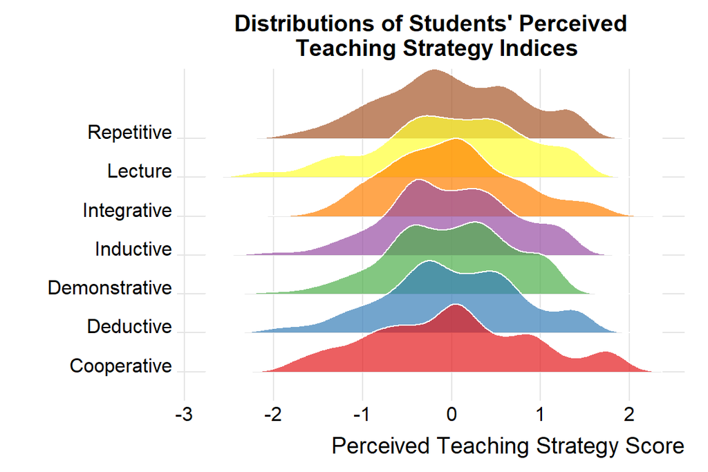

```r
var.name <-c( "Cooporative.cfa", "Deductive.cfa", "Demonstration.cfa",
              "Inductive.cfa", "Integrative.cfa", "LectureType.cfa",
              "Repetitive.cfa")
# <-c( "Cooporative.avg", "Deductive.avg", "Demonstration.avg",
#              "Inductive.avg", "Integrative.avg", "LectureType.avg",
#              "Repetitive.avg")
all.composite.scores <- final.anxiety.dat[, var.name]
names(all.composite.scores) <- c("Cooperative", "Deductive", "Demonstrative",
              "Inductive", "Integrative", "Lecture",   "Repetitive")

# For older versions of tidyr
long_data <- all.composite.scores %>%
  pivot_longer(
    cols = c( Cooperative, Deductive, Demonstrative, Inductive, Integrative, Lecture, Repetitive),  # Columns to reshape
    names_to = "variable",          # New column name for variable names
    values_to = "value"             # New column name for values
  )

## Summarized stats

summary_stats <- long_data %>%
  group_by(variable) %>%
  summarise(
    mean_val = mean(value),
    median_val = median(value),
    sd_val = sd(value),
    n = n(),
    .groups = 'drop'
  )

# Create ridge plot with ggridges and convert to plotly
ridge_gg <- ggplot(long_data, aes(x = value, y = variable, fill = variable
  )) +
  geom_density_ridges(
    alpha = 0.7,
    scale = 2,  # Adjust overlap
    color = "white",
    size = 0.5,
     ) +
  scale_fill_brewer(palette = "Set1") +
  #theme(plot.title = element_text(hjust = 0)) +
  theme_ridges() +
  labs(
    title = "Distributions of Students' Perceived \n Teaching Strategy Indices",
    x = "Perceived Teaching Strategy Score",
    y = ""
  ) +
  theme(legend.position = "none",
        plot.title = element_text(hjust = 0.5))

ridge_gg
```

```r
# Convert to plotly
#ggplotly(ridge_gg)
```

| Teacher-centered | Student-centered |
| --- | --- |
| **Deductive** (Teacher provides rules and examples: Joyce et al., 2015) | **Cooperative** (Students work together: Johnson, 2014) |
| **Lecture Type** (Teacher transmits information: Brown,2007) | **Inductive** (Students discover rules: Bruner, 1961; Prince & Felder, 2006) |
| **Demonstrative** (Teacher shows how: Borich, 2017) | **Integrative** (Students connect ideas: Jacobs, 1989; Fogarty,1991) |
| **Repetitive** (Teacher drills the information: Ormrod, 2020) |  |

The above classification is consistent with the one based on cognitive demand (Bloom’s Taxonomy), which categorizes strategies as requiring either lower-level thinking (remember, understand) or higher-level thinking (apply, analyze, evaluate, create).

**Note**: The **Demonstrative Approach sub-scale** in this survey measures constructs associated with both **Traditional Teacher-Centered** and **Student-Centered Strategies**. It encompasses not only the teacher’s direct demonstration of knowledge but also the use of these demonstrations to facilitate student-led solution building, characterizing it as a hybrid teaching strategy.

This classification demonstrates a spectrum of pedagogical approaches, from traditional, highly structured methods like Lecture and Deductive teaching, to modern, student-driven methods like Inductive, Cooperative, and Integrative learning. Demonstration and Repetitive practice serve specific, often complementary, roles within this spectrum.

## 10.1 Teaching Strategies Modulate the Triad

Teaching strategies are not merely methods of content delivery; they are powerful environmental forces that directly shape students’ emotional and self-evaluative landscapes.

**Teacher-Centered Strategies**

- **Lecture-type and Deductive Approaches**: These methods, where the instructor presents established rules and procedures first (deductive) in a largely one-way format (lecture), can inadvertently exacerbate the triad’s negative potential. For a student with low self-efficacy or high anxiety, the rapid, impersonal pace of a lecture can reinforce feelings of inadequacy and inability to keep up. The focus on a single “correct” method can stifle the exploratory behaviors that build genuine understanding and confidence.
- **Repetitive (Drill-and-Practice) Approach**: While necessary for developing procedural fluency, an over-reliance on repetitive practice can be a double-edged sword. For highly efficacious students, it can solidify skills. However, for anxious students, it can become a source of immense stress, framing mathematics as a monotonous, performance-oriented subject where mistakes are failures. This can directly undermine self-efficacy, as noted by researchers who found that environments overly focused on speed and correct answers increase anxiety (Ramirez et al., 2018).

**Student-Centered Strategies**

## 10.2 Create Single Composite Score for the Classification

We next define two single indices to represent the teaching strategies based on the above classification. We conceptualize teacher-centered and student-centered strategies as two single-factor constructs. The indices are defined using a doubly weighted average of the principal components. Following common practice, we report the validity and reliability measures before calculating the composite scores for the two classified teaching strategies.

**Validity Measures**

```r
var.name <-c("Cooporative.cfa", "Deductive.cfa", "Demonstration.cfa",
              "Inductive.cfa", "Integrative.cfa", "LectureType.cfa",
              "Repetitive.cfa")
Stratege.wt.pca <- final.anxiety.dat[, var.name]
names(Stratege.wt.pca) <- c("Cooperative", "Deductive", "Demonstrative",
              "Inductive", "Integrative", "Lecture",   "Repetitive")
##
teacher0 <- Stratege.wt.pca[,c("Deductive", "Demonstrative", "Lecture", "Repetitive")]
student0 <- Stratege.wt.pca[,c("Cooperative", "Inductive", "Integrative", "Deductive")]
###
teacher.vlid <-cfa.analysis(teacher0)
student.vlid <-cfa.analysis(student0)
##
vlid.table <-rbind(teacher.ctrd = teacher.vlid, student.ctrd = student.vlid)
row.name <- c("teacher.ctrd", "student.ctrd")
rownames(vlid.table) <- row.name
colnames(vlid.table) <- c("std.all.min",    "pval.max", "srmr", "cfi",  "tli")
pander(vlid.table)
```

|  | std.all.min | pval.max | srmr | cfi | tli |
| --- | --- | --- | --- | --- | --- |
| **teacher.ctrd** | 0.5581 | 0 | 2.553e-09 | 1 | 1 |
| **student.ctrd** | 0.4834 | 0 | 6.946e-09 | 1 | 1 |

**Reliability Measures**

```r
teacher <- Stratege.wt.pca[,c("Deductive", "Demonstrative", "Lecture", "Repetitive")]
student <- Stratege.wt.pca[,c("Cooperative", "Inductive", "Integrative")]
##
teacher.reliability <- Reliability.fun(teacher)
student.reliability <- Reliability.fun(student)
##
Rel.table <-rbind(teach = anxiety.mea.rel, anxiety.mla = anxiety.mla.rel)
row.name <- c("Teacher", "Student")
col.name <- c("Cronbach alpha", "McDonald's Omega")
rownames(Rel.table) <- row.name
colnames(Rel.table) <- col.name
pander(Rel.table)
```

[output not shown]

The above goodness-of-fit and reliability measures exceed the required thresholds of validity and reliability of an instrument. The **doubly weighted average** of the original composite scores of teaching strategies and appended to the analytic dataset.

```r
######################################
#####
scores = function(df, dn){
  ###########################
  ## single factor score
  ##########################
  x.var <- names(df)
  n0 <- length(x.var)
  cfa.model <-  paste("latent =~", paste(x.var, collapse = " + "))
  cfa.fit <- cfa(cfa.model, data = df)#, estimator = "MLM")
  composite.cfa <- lavPredict(cfa.fit)
  ##########################
  # pca analysis
  ##########################
  pca.mdl <- prcomp(df, scale = TRUE)
  pca0 <- pca.mdl$x[, 1]
  r0 = cor(pca0, composite.cfa)
  if(r0 < 0) {
     pca.all <- -pca.mdl$x
  }else{
    pca.all <- pca.mdl$x
  }
  first.pca = pca.all[,1]
  ##########################
  # weighted pca score
  ##########################
  var.explained <-((pca.mdl$sdev)^2) / sum((pca.mdl$sdev)^2) #
  composite_weighted_pca <- as.matrix(pca.all) %*% (var.explained)

  outdata <- as.data.frame(cbind(pca1 = first.pca,
                           wt.pca = as.vector(composite_weighted_pca),
                           cfa = as.vector(composite.cfa)))
  names(outdata) <- paste0(dn,".", names(outdata), sep = "")
  outdata
}

###
teacher <- scores(teacher, "Teacher.ctrd")
student <- scores(student, "Student.ctrd")
Anxiety.Analytic.Data <- cbind(na.omit(finalDat), teacher, student)
```

**The final clean data set with all variables used in descriptive and inferential analyses**

```r
final.var <- c("sex", "race", "class", "major", "math.level", "modality", "Anxiety.mea.cfa", "Anxiety.mla.cfa", "SelfEfficacy.cfa", "Technology.cfa",
               "Cooporative.cfa", "Deductive.cfa", "Demonstration.cfa", "Inductive.cfa", "Integrative.cfa", "LectureType.cfa",
               "Repetitive.cfa", "Engage.cfa", "Resource.cfa", "Teacher.ctrd.cfa", "Student.ctrd.cfa")
final.clean.analytic.data <- Anxiety.Analytic.Data[, final.var]
final.name <- c("sex", "race", "class", "major", "math.level", "modality", "mea", "mla", "selfEfficacy", "technology",
               "cooperative", "deductive", "demonstrative", "inductive", "integrative", "lecture",
               "repetitive", "engage", "resource", "teacher.ctrd", "student.ctrd")
colnames(final.clean.analytic.data) <- final.name
#write.csv(final.clean.analytic.data, "C:\\Users\\75CPENG\\OneDrive - West Chester University of PA\\Desktop\\cpeng\\WCU-Research\\2026\\AnxietyPapers\\CleanData\\TidyRegData.csv")
```

## 10.3 Influence of Math Maturity

```r
#Anxiety.Analytic.Data <- read.csv("C:\\Users\\75CPENG\\OneDrive - West Chester University of PA\\Desktop\\cpeng\\WCU-Teaching\\2025Fall\\MathAxiety\\Anxiety.Analytic.Data.csv")
```

```r
group.var <- c("sex", "math.level", "Anxiety.mea.cfa", "Anxiety.mla.cfa", "SelfEfficacy.cfa", "Student.ctrd.cfa","Teacher.ctrd.cfa")
group.strategy <- Anxiety.Analytic.Data[, group.var]
names(group.strategy) <-c("gender", "math.level", "anxiety.mea", "anxiety.mla", "self.efficacy", "student.ctrd", "teacher.ctrd")
##
group.strategy.loess <- data.frame(
  mla.index <- rep(group.strategy$anxiety.mla, 2),
  gender <- rep(group.strategy$gender,2),
  factor.index <-c(group.strategy$student.ctrd, group.strategy$teacher.ctrd),
  RelatedFactors <- rep(c("student.ctrd", "teacher.ctrd"), each = 693),
  math.level <- rep(group.strategy$math.level,2)
)
names(group.strategy.loess) <- c("mla.index", "gender", "factor.index", "RelatedFactors", "math.level")

level01.id <- which(group.strategy.loess$math.level %in% c("math02", "stats"))
level02.id <- which(group.strategy.loess$math.level %in% c("math03", "math04"))
##
level01.data <-group.strategy.loess[level01.id , ]
level01.data$gender.level <- paste0(level01.data$gender, " & ", level01.data$math.level)
##
level02.data <-group.strategy.loess[level02.id , ]
level02.data$gender.level <- paste0(level02.data$gender, " & ", level02.data$math.level)
```

```r
gg <- ggplot(level01.data, aes(x = mla.index, y = factor.index, color = RelatedFactors, group = RelatedFactors)) +
  #geom_point(alpha = 0.5, size = 1.5) +
  geom_smooth(method = "loess", span = 0.75, se = FALSE, size = 1) +
  facet_wrap(~ gender.level, ncol = 2, nrow = 2) +
  scale_color_viridis_d(option = "plasma") +
  labs(title = "Loess Plots: Teaching Strategy vs Learning Anxiety",
       x = "Math Learning Anxiety",
       y = "Teaching Strategy Index") +
  theme_minimal() +
  theme(
    strip.background = element_rect(fill = "lightgray"),
    strip.text = element_text(face = "bold"),
    plot.title = element_text(hjust = 0.5)
  )

gg
# Convert to interactive plotly
#ggplotly(gg) %>%
#  layout(
#    hovermode = "x unified",
#    legend = list(
#      orientation = "h",
#      x = 0.5,
#      xanchor = "center",
#      y = -0.1
#    )
#  )
```

[output not shown]

```r
gg <- ggplot(level02.data, aes(x = mla.index, y = factor.index, color = RelatedFactors, group = RelatedFactors)) +
  #geom_point(alpha = 0.5, size = 1.5) +
  geom_smooth(method = "loess", span = 0.75, se = FALSE, size = 1) +
  facet_wrap(~ gender.level, ncol = 2, nrow = 2) +
  scale_color_viridis_d(option = "plasma") +
  labs(title = "Loess Plots: Teaching Strategy vs Learning Anxiety",
       x = "Math Learning Anxiety",
       y = "Teaching Strategy Index") +
  theme_minimal() +
  theme(
    strip.background = element_rect(fill = "lightgray"),
    strip.text = element_text(face = "bold"),
    plot.title = element_text(hjust = 0.5)
  )

 #gg
# Convert to interactive plotly
#ggplotly(gg) %>%
#  layout(
#    hovermode = "x unified",
#    legend = list(
#      orientation = "h",
#      x = 0.5,
#      xanchor = "center",
#      y = -0.1
#    )
#  )
```

```r
group.var <- c("sex", "math.level", "Anxiety.mea.cfa", "Anxiety.mla.cfa", "SelfEfficacy.cfa", "Student.ctrd.cfa","Teacher.ctrd.cfa")
group.strategy <- Anxiety.Analytic.Data[, group.var]
names(group.strategy) <-c("gender", "math.level", "anxiety.mea", "anxiety.mla", "self.efficacy", "student.ctrd", "teacher.ctrd")
##
group.strategy.loess.mea <- data.frame(
  mea.index <- rep(group.strategy$anxiety.mea, 2),
  gender <- rep(group.strategy$gender,2),
  factor.index <-c(group.strategy$student.ctrd, group.strategy$teacher.ctrd),
  RelatedFactors <- rep(c("student.ctrd", "teacher.ctrd"), each = 693),
  math.level <- rep(group.strategy$math.level,2)
)
names(group.strategy.loess.mea) <- c("mea.index", "gender", "factor.index", "RelatedFactors", "math.level")

level01.id.mea <- which(group.strategy.loess.mea$math.level %in% c("math02", "stats"))
level02.id.mea <- which(group.strategy.loess.mea$math.level %in% c("math03", "math04"))
##
level01.data.mea <-group.strategy.loess.mea[level01.id.mea, ]
level01.data.mea$gender.level <- paste0(level01.data.mea$gender, " & ", level01.data.mea$math.level)
##
level02.data.mea <-group.strategy.loess.mea[level02.id.mea, ]
level02.data.mea$gender.level <- paste0(level02.data.mea$gender, " & ", level02.data.mea$math.level)
```

```r
gg <- ggplot(level01.data.mea, aes(x = mea.index, y = factor.index, color = RelatedFactors, group = RelatedFactors)) +
  #geom_point(alpha = 0.5, size = 1.5) +
  geom_smooth(method = "loess", span = 0.75, se = FALSE, size = 1) +
  facet_wrap(~ gender.level, ncol = 2, nrow = 2) +
  scale_color_viridis_d(option = "plasma") +
  labs(title = "Loess Plots: Teaching Strategy vs Test Anxiety",
       x = "Math Test Anxiety",
       y = "Teaching Strategy Index") +
  theme_minimal() +
  theme(
    strip.background = element_rect(fill = "lightgray"),
    strip.text = element_text(face = "bold"),
    plot.title = element_text(hjust = 0.5)
  )
#gg
# Convert to interactive plotly
#ggplotly(gg) %>%
#  layout(
#    hovermode = "x unified",
#    legend = list(
#      orientation = "h",
#      x = 0.5,
#      xanchor = "center",
#      y = -0.1
#    )
#  )
```

```r
gg <- ggplot(level02.data.mea, aes(x = mea.index, y = factor.index, color = RelatedFactors, group = RelatedFactors)) +
  #geom_point(alpha = 0.5, size = 1.5) +
  geom_smooth(method = "loess", span = 0.75, se = FALSE, size = 1) +
  facet_wrap(~ gender.level, ncol = 2, nrow = 2) +
  scale_color_viridis_d(option = "plasma") +
  labs(title = "Loess Plots: Teaching Strategy vs Test Anxiety",
       x = "Math Test Anxiety",
       y = "Teaching Strategy Index") +
  theme_minimal() +
  theme(
    strip.background = element_rect(fill = "lightgray"),
    strip.text = element_text(face = "bold"),
    plot.title = element_text(hjust = 0.5)
  )

 gg
# Convert to interactive plotly
#ggplotly(gg) %>%
#  layout(
#    hovermode = "x unified",
#    legend = list(
#      orientation = "h",
#      x = 0.5,
#      xanchor = "center",
#      y = -0.1
#    )
#  )
```

[output not shown]

# 11 Linear Regression Analysis

This section moves from the previous descriptive analyses to a regression analysis of the association between math anxiety and related factors. We examine two distinct but interconnected types of math anxiety, evaluation anxiety and learning anxiety, while temporarily setting aside their interconnection.

The regression model also incorporates the two teaching strategies as predictor variables. We also realized that the two variables are correlated.

## 11.1 Correlation Analysis

Next, we perform some correlation analysis of math anxiety and other factors

- Teaching Strategies

```r
reg.data <- read.csv("https://pengdsci.github.io/MathAnxiety/manuscript/RegData.csv")
```

```r
cor.name <- c("MEA", "MLA", "SelfEfficacy",  "Cooperative", "Deductive", "Demonstration", "Inductive",    "Integrative", "Lecture", "Repetitive")
cor.data <- reg.data[, cor.name]
abrre.name <- c("MEA", "MLA", "Self",  "Coop", "Ded", "Dem", "Ind", "Int", "Lec", "Rep")
colnames(cor.data) <- abrre.name
#rownames(cor.data) <- abrre.name
pander(round(cor(cor.data),2))
```

Table continues below

|  | MEA | MLA | Self | Coop | Ded | Dem | Ind | Int |
| --- | --- | --- | --- | --- | --- | --- | --- | --- |
| **MEA** | 1 | 0.58 | -0.42 | -0.2 | -0.26 | -0.21 | -0.22 | -0.19 |
| **MLA** | 0.58 | 1 | -0.45 | -0.17 | -0.31 | -0.3 | -0.3 | -0.15 |
| **Self** | -0.42 | -0.45 | 1 | 0.14 | 0.25 | 0.21 | 0.23 | 0.13 |
| **Coop** | -0.2 | -0.17 | 0.14 | 1 | 0.67 | 0.57 | 0.6 | 0.6 |
| **Ded** | -0.26 | -0.31 | 0.25 | 0.67 | 1 | 0.74 | 0.8 | 0.64 |
| **Dem** | -0.21 | -0.3 | 0.21 | 0.57 | 0.74 | 1 | 0.77 | 0.6 |
| **Ind** | -0.22 | -0.3 | 0.23 | 0.6 | 0.8 | 0.77 | 1 | 0.6 |
| **Int** | -0.19 | -0.15 | 0.13 | 0.6 | 0.64 | 0.6 | 0.6 | 1 |
| **Lec** | -0.31 | -0.38 | 0.28 | 0.66 | 0.78 | 0.74 | 0.78 | 0.56 |
| **Rep** | -0.2 | -0.19 | 0.17 | 0.62 | 0.65 | 0.64 | 0.63 | 0.64 |

|  | Lec | Rep |
| --- | --- | --- |
| **MEA** | -0.31 | -0.2 |
| **MLA** | -0.38 | -0.19 |
| **Self** | 0.28 | 0.17 |
| **Coop** | 0.66 | 0.62 |
| **Ded** | 0.78 | 0.65 |
| **Dem** | 0.74 | 0.64 |
| **Ind** | 0.78 | 0.63 |
| **Int** | 0.56 | 0.64 |
| **Lec** | 1 | 0.62 |
| **Rep** | 0.62 | 1 |

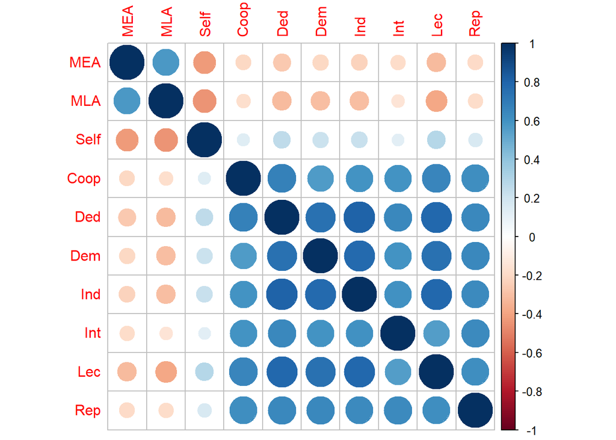

```r
library(corrplot)
corrplot(cor(cor.data))
```

```r
library(Hmisc)
rcorr(as.matrix(cor.data))
```

```
       MEA   MLA  Self  Coop   Ded   Dem   Ind   Int   Lec   Rep
MEA   1.00  0.58 -0.42 -0.20 -0.26 -0.21 -0.22 -0.19 -0.31 -0.20
MLA   0.58  1.00 -0.45 -0.17 -0.31 -0.30 -0.30 -0.15 -0.38 -0.19
Self -0.42 -0.45  1.00  0.14  0.25  0.21  0.23  0.13  0.28  0.17
Coop -0.20 -0.17  0.14  1.00  0.67  0.57  0.60  0.60  0.66  0.62
Ded  -0.26 -0.31  0.25  0.67  1.00  0.74  0.80  0.64  0.78  0.65
Dem  -0.21 -0.30  0.21  0.57  0.74  1.00  0.77  0.60  0.74  0.64
Ind  -0.22 -0.30  0.23  0.60  0.80  0.77  1.00  0.60  0.78  0.63
Int  -0.19 -0.15  0.13  0.60  0.64  0.60  0.60  1.00  0.56  0.64
Lec  -0.31 -0.38  0.28  0.66  0.78  0.74  0.78  0.56  1.00  0.62
Rep  -0.20 -0.19  0.17  0.62  0.65  0.64  0.63  0.64  0.62  1.00

n= 696


P
     MEA   MLA   Self  Coop  Ded   Dem   Ind   Int   Lec   Rep
MEA        0e+00 0e+00 0e+00 0e+00 0e+00 0e+00 0e+00 0e+00 0e+00
MLA  0e+00       0e+00 0e+00 0e+00 0e+00 0e+00 1e-04 0e+00 0e+00
Self 0e+00 0e+00       3e-04 0e+00 0e+00 0e+00 6e-04 0e+00 0e+00
Coop 0e+00 0e+00 3e-04       0e+00 0e+00 0e+00 0e+00 0e+00 0e+00
Ded  0e+00 0e+00 0e+00 0e+00       0e+00 0e+00 0e+00 0e+00 0e+00
Dem  0e+00 0e+00 0e+00 0e+00 0e+00       0e+00 0e+00 0e+00 0e+00
Ind  0e+00 0e+00 0e+00 0e+00 0e+00 0e+00       0e+00 0e+00 0e+00
Int  0e+00 1e-04 6e-04 0e+00 0e+00 0e+00 0e+00       0e+00 0e+00
Lec  0e+00 0e+00 0e+00 0e+00 0e+00 0e+00 0e+00 0e+00       0e+00
Rep  0e+00 0e+00 0e+00 0e+00 0e+00 0e+00 0e+00 0e+00 0e+00
```

- Association analysis of other factors and anxiety.

Pearson correlation coefficients and the p-value of their corresponding significant tests.

```r
other.name <- c("MEA", "MLA", "Technology", "Engage", "Resource","TeacherCtrd", "StudentCtrd")
other.data <- reg.data[, other.name]
rcorr(as.matrix(other.data))
```

```
              MEA   MLA Technology Engage Resource TeacherCtrd StudentCtrd
MEA          1.00  0.58      -0.24  -0.13     0.04       -0.29       -0.24
MLA          0.58  1.00      -0.29  -0.14     0.15       -0.35       -0.24
Technology  -0.24 -0.29       1.00   0.02    -0.03        0.11        0.03
Engage      -0.13 -0.14       0.02   1.00     0.21        0.22        0.21
Resource     0.04  0.15      -0.03   0.21     1.00       -0.01        0.07
TeacherCtrd -0.29 -0.35       0.11   0.22    -0.01        1.00        0.88
StudentCtrd -0.24 -0.24       0.03   0.21     0.07        0.88        1.00

n= 696


P
            MEA    MLA    Technology Engage Resource TeacherCtrd StudentCtrd
MEA                0.0000 0.0000     0.0006 0.2389   0.0000      0.0000
MLA         0.0000        0.0000     0.0002 0.0001   0.0000      0.0000
Technology  0.0000 0.0000            0.6427 0.3908   0.0033      0.4779
Engage      0.0006 0.0002 0.6427            0.0000   0.0000      0.0000
Resource    0.2389 0.0001 0.3908     0.0000          0.7818      0.0536
TeacherCtrd 0.0000 0.0000 0.0033     0.0000 0.7818               0.0000
StudentCtrd 0.0000 0.0000 0.4779     0.0000 0.0536   0.0000
```

## 11.2 Factors Associated with Evaluation Anxiety

### 11.2.1 Pairwise Comparison

We used an ANOVA approach to assess differences in anxiety across genders and learning modalities.

- **Gender**

```r
lm.m1 <- lm(MEA ~ sex, data = reg.data)
lm.m1
```

```
Call:
lm(formula = MEA ~ sex, data = reg.data)

Coefficients:
(Intercept)      sexmale
     0.1553      -0.4834
```

```r
aov.m1 <- aov(MEA ~ sex, data = reg.data)
summary(aov.m1)
```

```
             Df Sum Sq Mean Sq F value   Pr(>F)
sex           1   35.4   35.39   38.15 1.11e-09 ***
Residuals   693  642.8    0.93
---
Signif. codes:  0 '***' 0.001 '**' 0.01 '*' 0.05 '.' 0.1 ' ' 1
1 observation deleted due to missingness
```

```r
TukeyHSD(aov.m1)
```

```
  Tukey multiple comparisons of means
    95% family-wise confidence level

Fit: aov(formula = MEA ~ sex, data = reg.data)

$sex
                  diff        lwr        upr p adj
male-female -0.4833837 -0.6370342 -0.3297331     0
```

```r
lm.m2 <- lm(MLA ~ sex, data = reg.data)
lm.m2
```

```
Call:
lm(formula = MLA ~ sex, data = reg.data)

Coefficients:
(Intercept)      sexmale
    0.02425     -0.07866
```

```r
aov.m2 <- aov(MLA ~ sex, data = reg.data)
summary(aov.m2)
```

```
             Df Sum Sq Mean Sq F value Pr(>F)
sex           1   0.94  0.9370   5.055 0.0249 *
Residuals   693 128.46  0.1854
---
Signif. codes:  0 '***' 0.001 '**' 0.01 '*' 0.05 '.' 0.1 ' ' 1
1 observation deleted due to missingness
```

```r
TukeyHSD(aov.m2)
```

```
  Tukey multiple comparisons of means
    95% family-wise confidence level

Fit: aov(formula = MLA ~ sex, data = reg.data)

$sex
                   diff        lwr          upr     p adj
male-female -0.07865634 -0.1473475 -0.009965169 0.0248753
```

- **Modality**

```r
lm.m1 <- lm(MEA ~ modality, data = reg.data)
lm.m1
```

```
Call:
lm(formula = MEA ~ modality, data = reg.data)

Coefficients:
        (Intercept)  modalityKinesthetic       modalityVisual
           -0.10791              0.18312              0.09308
```

```r
aov.m1 <- aov(MEA ~ modality, data = reg.data)
summary(aov.m1)
```

```
             Df Sum Sq Mean Sq F value Pr(>F)
modality      2    3.5  1.7433   1.791  0.168
Residuals   693  674.7  0.9736
```

```r
TukeyHSD(aov.m1)
```

```
  Tukey multiple comparisons of means
    95% family-wise confidence level

Fit: aov(formula = MEA ~ modality, data = reg.data)

$modality
                            diff         lwr       upr     p adj
Kinesthetic-Auditory  0.18312328 -0.04715782 0.4134044 0.1488846
Visual-Auditory       0.09307684 -0.14058163 0.3267353 0.6179161
Visual-Kinesthetic   -0.09004645 -0.29021557 0.1101227 0.5414419
```

```r
lm.m2 <- lm(MLA ~ modality, data = reg.data)
lm.m2
```

```
Call:
lm(formula = MLA ~ modality, data = reg.data)

Coefficients:
        (Intercept)  modalityKinesthetic       modalityVisual
           -0.02168              0.03089              0.02508
```

```r
aov.m2 <- aov(MLA ~ modality, data = reg.data)
summary(aov.m2)
```

```
             Df Sum Sq Mean Sq F value Pr(>F)
modality      2    0.1 0.05069   0.271  0.763
Residuals   693  129.8 0.18726
```

```r
TukeyHSD(aov.m2)
```

```
  Tukey multiple comparisons of means
    95% family-wise confidence level

Fit: aov(formula = MLA ~ modality, data = reg.data)

$modality
                             diff         lwr       upr     p adj
Kinesthetic-Auditory  0.030889073 -0.07010546 0.1318836 0.7527015
Visual-Auditory       0.025076964 -0.07739878 0.1275527 0.8336341
Visual-Kinesthetic   -0.005812109 -0.09360041 0.0819762 0.9867578
```

- **Grouped Teaching Strategies**

```r
m1 <- lm(MEA ~ TeacherCtrd + StudentCtrd, data =reg.data)
summary(m1)
```

```
Call:
lm(formula = MEA ~ TeacherCtrd + StudentCtrd, data = reg.data)

Residuals:
    Min      1Q  Median      3Q     Max
-3.0887 -0.6101 -0.0077  0.7305  2.1200

Coefficients:
              Estimate Std. Error t value Pr(>|t|)
(Intercept)  1.971e-16  3.589e-02   0.000    1.000
TeacherCtrd -5.271e-01  1.160e-01  -4.543 6.56e-06 ***
StudentCtrd  1.016e-01  1.204e-01   0.844    0.399
---
Signif. codes:  0 '***' 0.001 '**' 0.01 '*' 0.05 '.' 0.1 ' ' 1

Residual standard error: 0.9469 on 693 degrees of freedom
Multiple R-squared:  0.08377,   Adjusted R-squared:  0.08113
F-statistic: 31.68 on 2 and 693 DF,  p-value: 6.822e-14
```

```r
m2 <- lm(MLA ~ TeacherCtrd + StudentCtrd, data =reg.data)
summary(m2)
```

```
Call:
lm(formula = MLA ~ TeacherCtrd + StudentCtrd, data = reg.data)

Residuals:
     Min       1Q   Median       3Q      Max
-0.95752 -0.29304 -0.09158  0.21903  1.63707

Coefficients:
              Estimate Std. Error t value Pr(>|t|)
(Intercept) -2.603e-17  1.517e-02   0.000        1
TeacherCtrd -4.094e-01  4.906e-02  -8.346 3.83e-16 ***
StudentCtrd  2.038e-01  5.092e-02   4.002 6.96e-05 ***
---
Signif. codes:  0 '***' 0.001 '**' 0.01 '*' 0.05 '.' 0.1 ' ' 1

Residual standard error: 0.4003 on 693 degrees of freedom
Multiple R-squared:  0.1448,    Adjusted R-squared:  0.1423
F-statistic: 58.67 on 2 and 693 DF,  p-value: < 2.2e-16
```

For the association analysis, we will build two regression models. Both models include a common set of demographic predictors. The first model uses individual teaching strategies as additional predictors, while the second uses grouped teaching strategies.

## 11.3 Linear Regression Using Individual Teaching Strategies

The analysis begins with a regression model incorporating all individual teaching approaches alongside demographic and related variables as predictors.

- **Regression of MEA with Individual Teaching Strategies - Left Panel of Table 3**

```r
mea.lm.data.ind <- na.omit(reg.data[,-c(1, 3, 21,22)])
mea.ind.lm <- lm(MEA ~., data = mea.lm.data.ind)
stepwise.mea.ind <- stepAIC(mea.ind.lm, direction = "both", trace = 0)
#kable(summary(mea.ind.lm)$coef, caption = "Table 1. Tentative model with all predictor variables: Imfluence of individual teaching strategies on MEA")
pander(summary(stepwise.mea.ind)$coef, caption = "Table 3 (left panel). Association between math evaluation anxiety and perceived individual teaching strategies adjusted by demographics and environmental factors")
```

Table 3 (left panel). Association between math evaluation anxiety and perceived individual teaching strategies adjusted by demographics and environmental factors

|  | Estimate | Std. Error | t value | Pr(>\|t\|) |
| --- | --- | --- | --- | --- |
| **(Intercept)** | -0.008575 | 0.0951 | -0.09017 | 0.9282 |
| **sexmale** | -0.4061 | 0.07214 | -5.63 | 2.64e-08 |
| **math.levelmath02** | 0.1702 | 0.1144 | 1.488 | 0.1372 |
| **math.levelmath03** | 0.3396 | 0.1213 | 2.801 | 0.005246 |
| **math.levelmath04** | 0.3537 | 0.1429 | 2.475 | 0.01358 |
| **math.levelother** | -0.0662 | 0.1442 | -0.459 | 0.6464 |
| **math.levelstats** | -0.01092 | 0.1155 | -0.09453 | 0.9247 |
| **SelfEfficacy** | -0.1992 | 0.0196 | -10.17 | 1.059e-22 |
| **Technology** | -0.1827 | 0.04306 | -4.242 | 2.519e-05 |
| **Deductive** | -0.1172 | 0.07817 | -1.499 | 0.1343 |
| **Inductive** | 0.1403 | 0.08402 | 1.67 | 0.09538 |
| **Lecture** | -0.2061 | 0.06971 | -2.957 | 0.003215 |

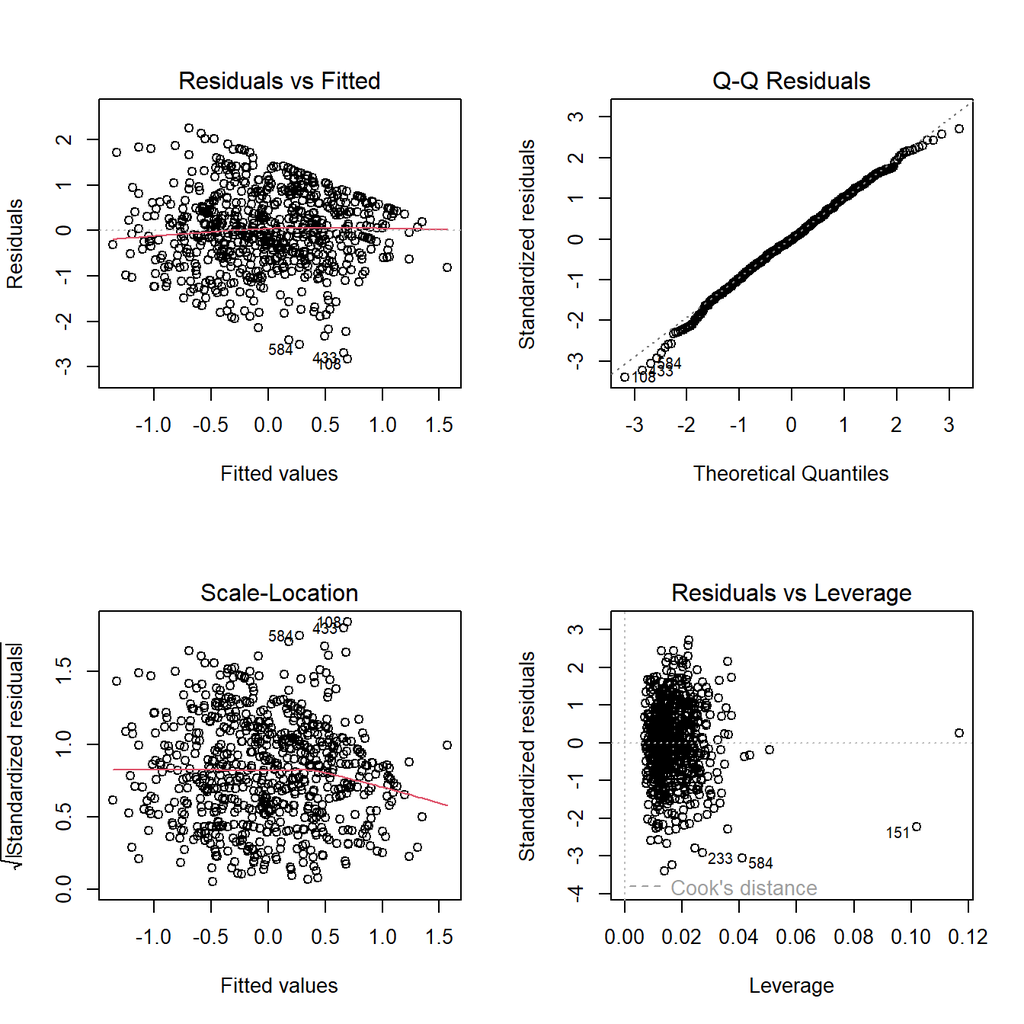

```r
par(mfrow = c(2,2))
plot(stepwise.mea.ind )
```

- **Regression of MLA with Individual Teaching Strategies - Right Panel of Table 3**

```r
mla.lm.data.ind <- na.omit(reg.data[,-c(1, 2, 21,22)])
mla.ind.lm <- lm(MLA ~., data = mla.lm.data.ind)
stepwise.mla.ind <- stepAIC(mla.ind.lm, direction = "both", trace = 0)
#kable(summary(mea.ind.lm)$coef, caption = "Table 1. Tentative model with all predictor variables: Imfluence of individual teaching strategies on MEA")
pander(summary(stepwise.mla.ind)$coef, caption = "Table 3 (right panel). Association between math learning anxiety and perceived individual teaching strategies adjusted by demographics and environmental factors")
```

Table 3 (right panel). Association between math learning anxiety and perceived individual teaching strategies adjusted by demographics and environmental factors

|  | Estimate | Std. Error | t value | Pr(>\|t\|) |
| --- | --- | --- | --- | --- |
| **(Intercept)** | -0.0008729 | 0.05953 | -0.01466 | 0.9883 |
| **raceBlack** | 0.142 | 0.07682 | 1.849 | 0.06496 |
| **raceother** | -0.001913 | 0.07586 | -0.02522 | 0.9799 |
| **racewhite** | -0.01448 | 0.06149 | -0.2354 | 0.8139 |
| **SelfEfficacy** | -0.08141 | 0.008363 | -9.734 | 4.665e-21 |
| **Technology** | -0.1168 | 0.01783 | -6.549 | 1.137e-10 |
| **Cooperative** | 0.04544 | 0.02169 | 2.095 | 0.03656 |
| **Deductive** | -0.04613 | 0.03069 | -1.503 | 0.1333 |
| **Lecture** | -0.1302 | 0.02863 | -4.549 | 6.38e-06 |
| **Resource** | 0.08211 | 0.03693 | 2.223 | 0.02651 |

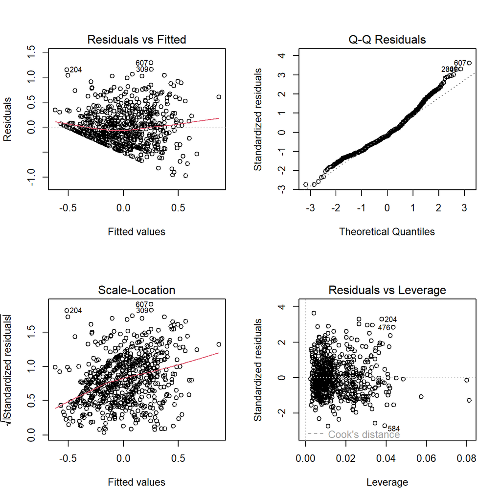

```r
par(mfrow = c(2,2))
plot(stepwise.mla.ind )
```